# IL CBS social survey

Author

Saar Alon-Barkat; s.alon.barkat@poli.haifa.ac.il

Published

September 13, 2022

```r
library(sjmisc)
library(sjPlot)
library(tidyverse)
library(ggthemes)
library(gt)
library(gtsummary)
```

This report summarizes first results from Israel CBS social surveys in years 2015-2020, focused on trust in government and trust in healthcare system.

**This is a preliminary report, reflecting work in progress. Please contact author before citing.**

Raw data obtained from the Israel CBS website: https://www.cbs.gov.il/he/subjects/Pages/%D7%94%D7%A1%D7%A7%D7%A8-%D7%94%D7%97%D7%91%D7%A8%D7%AA%D7%99.aspx

The data is analyzed and used in accordance with PUF license.

Information on the social survey available online at the Israel CBS website.

R code available at GitHub: https://github.com/saaralonbarkat/IL_CBS_social_survey

# The data

```r
load("~/GitHub/IL_CBS_social_survey/.RData")
#lss_comb <- read_csv("~/GitHub/IL_CBS_social_survey/data/lss_comb.csv")
```

```r
lss_comb %>%
  group_by(year) %>%
  summarise(n_participants = n()) %>%
  gt()
```

| year | n_participants |
| --- | --- |
| 2015 | 7078 |
| 2016 | 7048 |
| 2017 | 7230 |
| 2018 | 7448 |
| 2019 | 7575 |
| 2020 | 7249 |

```r
lss_comb %>%
  glimpse()
```

```
Rows: 43,628
Columns: 38
$ district                  <dbl> 3, 3, 2, 2, 5, 5, 6, 4, 2, 1, 5, 2, 4, 2, 4,~
$ subdistrict               <dbl> 31, 31, 24, 23, 51, 51, 62, 42, 24, 11, 51, ~
$ residence_type            <dbl> 16, 16, 16, 16, 14, 2, 16, 16, 16, 1, 2, 16,~
$ life_satisfaction         <dbl> 2, 3, 2, 1, 1, 2, 1, 1, 2, 2, 2, 2, NA, 2, 2~
$ trust_gov_raw             <dbl> 3, 2, NA, NA, NA, 2, 1, 3, 2, 4, 4, 3, 4, 3,~
$ trust_local_gov_raw       <dbl> 2, 3, 2, 2, NA, 1, 1, 1, 2, 1, 3, 3, 2, 2, 2~
$ year                      <dbl> 2015, 2015, 2015, 2015, 2015, 2015, 2015, 20~
$ religion                  <dbl> 1, 1, 2, 3, 1, 1, 1, 1, 1, 1, 1, 1, 1, 2, 1,~
$ arab                      <dbl> 0, 0, 1, 1, 0, 0, 0, 0, 0, 0, 0, 0, 0, 1, 0,~
$ ultra_orthodox            <dbl> 0, 0, NA, NA, 1, 0, 0, 1, 0, 0, 0, 0, 1, NA,~
$ female                    <dbl> 1, 0, 0, 1, 1, 1, 0, 1, 1, 1, 0, 0, 1, 0, 0,~
$ russian_ole               <dbl> 0, 0, 0, 0, 0, 0, 0, 0, 1, 0, 0, 0, 0, 0, 1,~
$ mizrahi_origin            <dbl> 1, 1, 0, 0, 0, 0, 1, 1, 0, 1, 1, 1, 1, 0, 0,~
```

[output cut: 25 more lines]

```r
lss_comb %>%
  select(year,
        female,
        age_g,
        sector,sector_multiple,
        russian_ole,
        mizrahi_origin,
        household_income,
        district_lab) %>%
  tbl_summary()
```

| **Characteristic** | **N = 43,628**<sup>1</sup> |
| --- | --- |
| year |  |
| 2015 | 7,078 (16%) |
| 2016 | 7,048 (16%) |
| 2017 | 7,230 (17%) |
| 2018 | 7,448 (17%) |
| 2019 | 7,575 (17%) |
| 2020 | 7,249 (17%) |
| female | 22,192 (51%) |
| age_g |  |
| 20-24 | 4,682 (11%) |
| 25-29 | 4,585 (11%) |
| 30-34 | 4,548 (10%) |
| 35-39 | 4,298 (9.9%) |
| 40-44 | 4,286 (9.8%) |
| 45-49 | 3,777 (8.7%) |
| 50-54 | 3,224 (7.4%) |
| 55-59 | 3,088 (7.1%) |
| 60-64 | 2,932 (6.7%) |
| 65-74 | 4,789 (11%) |
| 75+ | 3,419 (7.8%) |
| sector |  |
| 1.General | 32,339 (74%) |
| 2.Ultra-orthodox | 3,436 (7.9%) |
| 3.Arab | 7,853 (18%) |
| sector_multiple |  |
| Arab Christian | 698 (1.6%) |
| Arab Druz | 817 (1.9%) |
| Arab Jerusalem | 1,374 (3.1%) |
| Arab Muslim | 4,940 (11%) |
| Jewish Ashkenazi | 14,427 (33%) |
| Jewish Mizrahi origin | 10,903 (25%) |
| Jewish Ultra-orthodox | 3,436 (7.9%) |
| Jewish USSR born | 6,515 (15%) |
| Other | 518 (1.2%) |
| russian_ole | 6,614 (15%) |
| mizrahi_origin | 11,898 (27%) |
| household_income |  |
| 0. 0-2500 | 962 (2.8%) |
| 1. 2500-4000 | 2,053 (6.1%) |
| 2. 4000-5000 | 2,053 (6.1%) |
| 3. 5000-6500 | 2,642 (7.8%) |
| 4. 6500-8000 | 3,361 (9.9%) |
| 5. 8000-10000 | 4,134 (12%) |
| 6. 10000-13000 | 4,855 (14%) |
| 7. 13000-17000 | 5,590 (17%) |
| 8. 17000-24000 | 4,632 (14%) |
| 9. 24000+ | 3,568 (11%) |
| Unknown | 9,778 |
| district_lab |  |
| 1.Jerusalem | 4,888 (11%) |
| 2.North | 7,601 (17%) |
| 3.Haifa | 5,460 (13%) |
| 4.Center | 10,951 (25%) |
| 5.Tel Aviv | 7,575 (17%) |
| 6.South | 5,592 (13%) |
| 7.Yosh | 1,561 (3.6%) |

<sup>*1*</sup> n (%)

```r
lss_comb %>%
  select(year,
        female,
        age_g,
        sector,sector_multiple,
        russian_ole,
        mizrahi_origin,
        household_income,
        district_lab) %>%
  tbl_summary(by = year)
```

| **Characteristic** | **2015**, N = 7,078<sup>1</sup> | **2016**, N = 7,048<sup>1</sup> | **2017**, N = 7,230<sup>1</sup> | **2018**, N = 7,448<sup>1</sup> | **2019**, N = 7,575<sup>1</sup> | **2020**, N = 7,249<sup>1</sup> |
| --- | --- | --- | --- | --- | --- | --- |
| female | 3,605 (51%) | 3,680 (52%) | 3,670 (51%) | 3,766 (51%) | 3,824 (50%) | 3,647 (50%) |
| age_g |  |  |  |  |  |  |
| 20-24 | 765 (11%) | 746 (11%) | 769 (11%) | 829 (11%) | 801 (11%) | 772 (11%) |
| 25-29 | 785 (11%) | 710 (10%) | 739 (10%) | 740 (9.9%) | 806 (11%) | 805 (11%) |
| 30-34 | 731 (10%) | 744 (11%) | 775 (11%) | 740 (9.9%) | 800 (11%) | 758 (10%) |
| 35-39 | 711 (10%) | 679 (9.6%) | 698 (9.7%) | 732 (9.8%) | 735 (9.7%) | 743 (10%) |
| 40-44 | 706 (10.0%) | 698 (9.9%) | 721 (10.0%) | 710 (9.5%) | 735 (9.7%) | 716 (9.9%) |
| 45-49 | 554 (7.8%) | 620 (8.8%) | 633 (8.8%) | 665 (8.9%) | 656 (8.7%) | 649 (9.0%) |
| 50-54 | 536 (7.6%) | 524 (7.4%) | 522 (7.2%) | 531 (7.1%) | 563 (7.4%) | 548 (7.6%) |
| 55-59 | 529 (7.5%) | 489 (6.9%) | 521 (7.2%) | 551 (7.4%) | 486 (6.4%) | 512 (7.1%) |
| 60-64 | 511 (7.2%) | 498 (7.1%) | 487 (6.7%) | 501 (6.7%) | 516 (6.8%) | 419 (5.8%) |
| 65-74 | 691 (9.8%) | 768 (11%) | 785 (11%) | 839 (11%) | 885 (12%) | 821 (11%) |
| 75+ | 559 (7.9%) | 572 (8.1%) | 580 (8.0%) | 610 (8.2%) | 592 (7.8%) | 506 (7.0%) |
| sector |  |  |  |  |  |  |
| 1.General | 5,290 (75%) | 5,141 (73%) | 5,291 (73%) | 5,598 (75%) | 5,576 (74%) | 5,443 (75%) |
| 2.Ultra-orthodox | 527 (7.4%) | 565 (8.0%) | 589 (8.1%) | 563 (7.6%) | 602 (7.9%) | 590 (8.1%) |
| 3.Arab | 1,261 (18%) | 1,342 (19%) | 1,350 (19%) | 1,287 (17%) | 1,397 (18%) | 1,216 (17%) |
| sector_multiple |  |  |  |  |  |  |
| Arab Christian | 114 (1.6%) | 93 (1.3%) | 134 (1.9%) | 134 (1.8%) | 111 (1.5%) | 112 (1.5%) |
| Arab Druz | 168 (2.4%) | 123 (1.7%) | 145 (2.0%) | 106 (1.4%) | 153 (2.0%) | 122 (1.7%) |
| Arab Jerusalem | 148 (2.1%) | 232 (3.3%) | 219 (3.0%) | 240 (3.2%) | 247 (3.3%) | 288 (4.0%) |
| Arab Muslim | 831 (12%) | 894 (13%) | 848 (12%) | 801 (11%) | 876 (12%) | 690 (9.5%) |
| Jewish Ashkenazi | 2,214 (31%) | 2,172 (31%) | 2,339 (32%) | 2,519 (34%) | 2,557 (34%) | 2,626 (36%) |
| Jewish Mizrahi origin | 1,877 (27%) | 1,832 (26%) | 1,817 (25%) | 1,860 (25%) | 1,838 (24%) | 1,679 (23%) |
| Jewish Ultra-orthodox | 527 (7.4%) | 565 (8.0%) | 589 (8.1%) | 563 (7.6%) | 602 (7.9%) | 590 (8.1%) |
| Jewish USSR born | 1,114 (16%) | 1,063 (15%) | 1,055 (15%) | 1,136 (15%) | 1,099 (15%) | 1,048 (14%) |
| Other | 85 (1.2%) | 74 (1.0%) | 84 (1.2%) | 89 (1.2%) | 92 (1.2%) | 94 (1.3%) |
| russian_ole | 1,131 (16%) | 1,084 (15%) | 1,067 (15%) | 1,150 (15%) | 1,119 (15%) | 1,063 (15%) |
| mizrahi_origin | 2,062 (29%) | 1,993 (28%) | 1,984 (27%) | 2,018 (27%) | 2,013 (27%) | 1,828 (25%) |
| household_income |  |  |  |  |  |  |
| 0. 0-2500 | 179 (3.2%) | 173 (3.1%) | 143 (2.5%) | 178 (3.0%) | 171 (2.9%) | 118 (2.4%) |
| 1. 2500-4000 | 420 (7.5%) | 373 (6.6%) | 315 (5.6%) | 326 (5.5%) | 316 (5.3%) | 303 (6.1%) |
| 2. 4000-5000 | 379 (6.7%) | 371 (6.6%) | 354 (6.3%) | 331 (5.6%) | 324 (5.4%) | 294 (5.9%) |
| 3. 5000-6500 | 484 (8.6%) | 443 (7.9%) | 445 (7.9%) | 453 (7.6%) | 424 (7.1%) | 393 (7.8%) |
| 4. 6500-8000 | 611 (11%) | 594 (11%) | 574 (10%) | 513 (8.6%) | 578 (9.7%) | 491 (9.8%) |
| 5. 8000-10000 | 717 (13%) | 717 (13%) | 725 (13%) | 705 (12%) | 684 (11%) | 586 (12%) |
| 6. 10000-13000 | 783 (14%) | 845 (15%) | 815 (14%) | 955 (16%) | 822 (14%) | 635 (13%) |
| 7. 13000-17000 | 928 (16%) | 931 (17%) | 944 (17%) | 1,021 (17%) | 997 (17%) | 769 (15%) |
| 8. 17000-24000 | 685 (12%) | 694 (12%) | 778 (14%) | 821 (14%) | 885 (15%) | 769 (15%) |
| 9. 24000+ | 446 (7.9%) | 499 (8.8%) | 539 (9.6%) | 658 (11%) | 777 (13%) | 649 (13%) |
| Unknown | 1,446 | 1,408 | 1,598 | 1,487 | 1,597 | 2,242 |
| district_lab |  |  |  |  |  |  |
| 1.Jerusalem | 712 (10%) | 824 (12%) | 781 (11%) | 815 (11%) | 854 (11%) | 902 (12%) |
| 2.North | 1,276 (18%) | 1,267 (18%) | 1,259 (17%) | 1,266 (17%) | 1,317 (17%) | 1,216 (17%) |
| 3.Haifa | 940 (13%) | 876 (12%) | 958 (13%) | 896 (12%) | 968 (13%) | 822 (11%) |
| 4.Center | 1,750 (25%) | 1,678 (24%) | 1,808 (25%) | 1,977 (27%) | 1,951 (26%) | 1,787 (25%) |
| 5.Tel Aviv | 1,161 (16%) | 1,260 (18%) | 1,286 (18%) | 1,342 (18%) | 1,262 (17%) | 1,264 (17%) |
| 6.South | 996 (14%) | 905 (13%) | 880 (12%) | 915 (12%) | 935 (12%) | 961 (13%) |
| 7.Yosh | 243 (3.4%) | 238 (3.4%) | 258 (3.6%) | 237 (3.2%) | 288 (3.8%) | 297 (4.1%) |

<sup>*1*</sup> n (%)

```r
lss_comb %>%
  select(year,
        female,
        age_g,
        sector,sector_multiple,
        russian_ole,
        mizrahi_origin,
        household_income,
        district_lab) %>%
  tbl_summary(by = sector)
```

| **Characteristic** | **1.General**, N = 32,339<sup>1</sup> | **2.Ultra-orthodox**, N = 3,436<sup>1</sup> | **3.Arab**, N = 7,853<sup>1</sup> |
| --- | --- | --- | --- |
| year |  |  |  |
| 2015 | 5,290 (16%) | 527 (15%) | 1,261 (16%) |
| 2016 | 5,141 (16%) | 565 (16%) | 1,342 (17%) |
| 2017 | 5,291 (16%) | 589 (17%) | 1,350 (17%) |
| 2018 | 5,598 (17%) | 563 (16%) | 1,287 (16%) |
| 2019 | 5,576 (17%) | 602 (18%) | 1,397 (18%) |
| 2020 | 5,443 (17%) | 590 (17%) | 1,216 (15%) |
| female | 16,538 (51%) | 1,684 (49%) | 3,970 (51%) |
| age_g |  |  |  |
| 20-24 | 2,851 (8.8%) | 589 (17%) | 1,242 (16%) |
| 25-29 | 2,913 (9.0%) | 537 (16%) | 1,135 (14%) |
| 30-34 | 3,150 (9.7%) | 537 (16%) | 861 (11%) |
| 35-39 | 3,053 (9.4%) | 409 (12%) | 836 (11%) |
| 40-44 | 3,098 (9.6%) | 361 (11%) | 827 (11%) |
| 45-49 | 2,845 (8.8%) | 233 (6.8%) | 699 (8.9%) |
| 50-54 | 2,372 (7.3%) | 186 (5.4%) | 666 (8.5%) |
| 55-59 | 2,422 (7.5%) | 180 (5.2%) | 486 (6.2%) |
| 60-64 | 2,430 (7.5%) | 136 (4.0%) | 366 (4.7%) |
| 65-74 | 4,153 (13%) | 179 (5.2%) | 457 (5.8%) |
| 75+ | 3,052 (9.4%) | 89 (2.6%) | 278 (3.5%) |
| sector_multiple |  |  |  |
| Arab Christian | 0 (0%) | 0 (0%) | 698 (8.9%) |
| Arab Druz | 0 (0%) | 0 (0%) | 817 (10%) |
| Arab Jerusalem | 0 (0%) | 0 (0%) | 1,374 (17%) |
| Arab Muslim | 0 (0%) | 0 (0%) | 4,940 (63%) |
| Jewish Ashkenazi | 14,427 (45%) | 0 (0%) | 0 (0%) |
| Jewish Mizrahi origin | 10,903 (34%) | 0 (0%) | 0 (0%) |
| Jewish Ultra-orthodox | 0 (0%) | 3,436 (100%) | 0 (0%) |
| Jewish USSR born | 6,515 (20%) | 0 (0%) | 0 (0%) |
| Other | 494 (1.5%) | 0 (0%) | 24 (0.3%) |
| russian_ole | 6,515 (20%) | 79 (2.3%) | 20 (0.3%) |
| mizrahi_origin | 11,024 (34%) | 874 (25%) | 0 (0%) |
| household_income |  |  |  |
| 0. 0-2500 | 491 (2.0%) | 108 (4.1%) | 363 (5.8%) |
| 1. 2500-4000 | 1,229 (4.9%) | 190 (7.2%) | 634 (10%) |
| 2. 4000-5000 | 1,203 (4.8%) | 251 (9.6%) | 599 (9.6%) |
| 3. 5000-6500 | 1,542 (6.2%) | 309 (12%) | 791 (13%) |
| 4. 6500-8000 | 2,083 (8.3%) | 470 (18%) | 808 (13%) |
| 5. 8000-10000 | 2,819 (11%) | 463 (18%) | 852 (14%) |
| 6. 10000-13000 | 3,686 (15%) | 380 (14%) | 789 (13%) |
| 7. 13000-17000 | 4,624 (18%) | 282 (11%) | 684 (11%) |
| 8. 17000-24000 | 4,084 (16%) | 115 (4.4%) | 433 (7.0%) |
| 9. 24000+ | 3,258 (13%) | 54 (2.1%) | 256 (4.1%) |
| Unknown | 7,320 | 814 | 1,644 |
| district_lab |  |  |  |
| 1.Jerusalem | 2,280 (7.1%) | 1,113 (32%) | 1,495 (19%) |
| 2.North | 3,437 (11%) | 163 (4.7%) | 4,001 (51%) |
| 3.Haifa | 4,117 (13%) | 145 (4.2%) | 1,198 (15%) |
| 4.Center | 9,871 (31%) | 464 (14%) | 616 (7.8%) |
| 5.Tel Aviv | 6,732 (21%) | 751 (22%) | 92 (1.2%) |
| 6.South | 4,765 (15%) | 378 (11%) | 449 (5.7%) |
| 7.Yosh | 1,137 (3.5%) | 422 (12%) | 2 (<0.1%) |

<sup>*1*</sup> n (%)

```r
lss_comb %>%
  select(year,
        female,
        age_g,
        sector,sector_multiple,
        russian_ole,
        mizrahi_origin,
        household_income,
        district_lab) %>%
  tbl_summary(by = sector_multiple)
```

| **Characteristic** | **Arab Christian**, N = 698<sup>1</sup> | **Arab Druz**, N = 817<sup>1</sup> | **Arab Jerusalem**, N = 1,374<sup>1</sup> | **Arab Muslim**, N = 4,940<sup>1</sup> | **Jewish Ashkenazi**, N = 14,427<sup>1</sup> | **Jewish Mizrahi origin**, N = 10,903<sup>1</sup> | **Jewish Ultra-orthodox**, N = 3,436<sup>1</sup> | **Jewish USSR born**, N = 6,515<sup>1</sup> | **Other**, N = 518<sup>1</sup> |
| --- | --- | --- | --- | --- | --- | --- | --- | --- | --- |
| year |  |  |  |  |  |  |  |  |  |
| 2015 | 114 (16%) | 168 (21%) | 148 (11%) | 831 (17%) | 2,214 (15%) | 1,877 (17%) | 527 (15%) | 1,114 (17%) | 85 (16%) |
| 2016 | 93 (13%) | 123 (15%) | 232 (17%) | 894 (18%) | 2,172 (15%) | 1,832 (17%) | 565 (16%) | 1,063 (16%) | 74 (14%) |
| 2017 | 134 (19%) | 145 (18%) | 219 (16%) | 848 (17%) | 2,339 (16%) | 1,817 (17%) | 589 (17%) | 1,055 (16%) | 84 (16%) |
| 2018 | 134 (19%) | 106 (13%) | 240 (17%) | 801 (16%) | 2,519 (17%) | 1,860 (17%) | 563 (16%) | 1,136 (17%) | 89 (17%) |
| 2019 | 111 (16%) | 153 (19%) | 247 (18%) | 876 (18%) | 2,557 (18%) | 1,838 (17%) | 602 (18%) | 1,099 (17%) | 92 (18%) |
| 2020 | 112 (16%) | 122 (15%) | 288 (21%) | 690 (14%) | 2,626 (18%) | 1,679 (15%) | 590 (17%) | 1,048 (16%) | 94 (18%) |
| female | 350 (50%) | 401 (49%) | 719 (52%) | 2,491 (50%) | 7,208 (50%) | 5,492 (50%) | 1,684 (49%) | 3,603 (55%) | 244 (47%) |
| age_g |  |  |  |  |  |  |  |  |  |
| 20-24 | 74 (11%) | 109 (13%) | 236 (17%) | 818 (17%) | 2,163 (15%) | 443 (4.1%) | 589 (17%) | 171 (2.6%) | 79 (15%) |
| 25-29 | 90 (13%) | 129 (16%) | 205 (15%) | 707 (14%) | 1,889 (13%) | 605 (5.5%) | 537 (16%) | 358 (5.5%) | 65 (13%) |
| 30-34 | 60 (8.6%) | 88 (11%) | 151 (11%) | 560 (11%) | 1,748 (12%) | 766 (7.0%) | 537 (16%) | 572 (8.8%) | 66 (13%) |
| 35-39 | 66 (9.5%) | 89 (11%) | 143 (10%) | 536 (11%) | 1,500 (10%) | 887 (8.1%) | 409 (12%) | 606 (9.3%) | 62 (12%) |
| 40-44 | 74 (11%) | 88 (11%) | 146 (11%) | 517 (10%) | 1,275 (8.8%) | 1,195 (11%) | 361 (11%) | 591 (9.1%) | 39 (7.5%) |
| 45-49 | 63 (9.0%) | 72 (8.8%) | 107 (7.8%) | 454 (9.2%) | 977 (6.8%) | 1,229 (11%) | 233 (6.8%) | 598 (9.2%) | 44 (8.5%) |
| 50-54 | 66 (9.5%) | 64 (7.8%) | 117 (8.5%) | 418 (8.5%) | 750 (5.2%) | 1,093 (10%) | 186 (5.4%) | 493 (7.6%) | 37 (7.1%) |
| 55-59 | 39 (5.6%) | 59 (7.2%) | 78 (5.7%) | 307 (6.2%) | 684 (4.7%) | 1,134 (10%) | 180 (5.2%) | 569 (8.7%) | 38 (7.3%) |
| 60-64 | 40 (5.7%) | 36 (4.4%) | 58 (4.2%) | 230 (4.7%) | 768 (5.3%) | 1,057 (9.7%) | 136 (4.0%) | 578 (8.9%) | 29 (5.6%) |
| 65-74 | 68 (9.7%) | 49 (6.0%) | 80 (5.8%) | 260 (5.3%) | 1,554 (11%) | 1,491 (14%) | 179 (5.2%) | 1,078 (17%) | 30 (5.8%) |
| 75+ | 58 (8.3%) | 34 (4.2%) | 53 (3.9%) | 133 (2.7%) | 1,119 (7.8%) | 1,003 (9.2%) | 89 (2.6%) | 901 (14%) | 29 (5.6%) |
| sector |  |  |  |  |  |  |  |  |  |
| 1.General | 0 (0%) | 0 (0%) | 0 (0%) | 0 (0%) | 14,427 (100%) | 10,903 (100%) | 0 (0%) | 6,515 (100%) | 494 (95%) |
| 2.Ultra-orthodox | 0 (0%) | 0 (0%) | 0 (0%) | 0 (0%) | 0 (0%) | 0 (0%) | 3,436 (100%) | 0 (0%) | 0 (0%) |
| 3.Arab | 698 (100%) | 817 (100%) | 1,374 (100%) | 4,940 (100%) | 0 (0%) | 0 (0%) | 0 (0%) | 0 (0%) | 24 (4.6%) |
| russian_ole | 1 (0.1%) | 0 (0%) | 1 (<0.1%) | 18 (0.4%) | 0 (0%) | 0 (0%) | 79 (2.3%) | 6,515 (100%) | 0 (0%) |
| mizrahi_origin | 0 (0%) | 0 (0%) | 0 (0%) | 0 (0%) | 0 (0%) | 10,903 (100%) | 874 (25%) | 0 (0%) | 121 (23%) |
| household_income |  |  |  |  |  |  |  |  |  |
| 0. 0-2500 | 15 (2.8%) | 24 (3.8%) | 145 (12%) | 179 (4.7%) | 202 (1.9%) | 185 (2.2%) | 108 (4.1%) | 90 (1.7%) | 14 (3.9%) |
| 1. 2500-4000 | 45 (8.4%) | 56 (8.8%) | 121 (9.9%) | 411 (11%) | 286 (2.7%) | 390 (4.6%) | 190 (7.2%) | 534 (9.9%) | 20 (5.5%) |
| 2. 4000-5000 | 31 (5.8%) | 37 (5.8%) | 178 (15%) | 351 (9.2%) | 305 (2.8%) | 375 (4.4%) | 251 (9.6%) | 502 (9.3%) | 23 (6.3%) |
| 3. 5000-6500 | 42 (7.8%) | 69 (11%) | 243 (20%) | 437 (12%) | 458 (4.3%) | 545 (6.4%) | 309 (12%) | 511 (9.5%) | 28 (7.7%) |
| 4. 6500-8000 | 54 (10%) | 72 (11%) | 181 (15%) | 501 (13%) | 785 (7.3%) | 772 (9.1%) | 470 (18%) | 499 (9.2%) | 27 (7.4%) |
| 5. 8000-10000 | 70 (13%) | 82 (13%) | 179 (15%) | 521 (14%) | 1,093 (10%) | 1,044 (12%) | 463 (18%) | 635 (12%) | 47 (13%) |
| 6. 10000-13000 | 74 (14%) | 100 (16%) | 126 (10%) | 484 (13%) | 1,486 (14%) | 1,325 (16%) | 380 (14%) | 828 (15%) | 52 (14%) |
| 7. 13000-17000 | 91 (17%) | 93 (15%) | 31 (2.5%) | 468 (12%) | 2,091 (19%) | 1,653 (19%) | 282 (11%) | 820 (15%) | 61 (17%) |
| 8. 17000-24000 | 70 (13%) | 60 (9.4%) | 14 (1.1%) | 284 (7.5%) | 2,111 (20%) | 1,305 (15%) | 115 (4.4%) | 619 (11%) | 54 (15%) |
| 9. 24000+ | 44 (8.2%) | 43 (6.8%) | 3 (0.2%) | 163 (4.3%) | 1,948 (18%) | 907 (11%) | 54 (2.1%) | 369 (6.8%) | 37 (10%) |
| Unknown | 162 | 181 | 153 | 1,141 | 3,662 | 2,402 | 814 | 1,108 | 155 |
| district_lab |  |  |  |  |  |  |  |  |  |
| 1.Jerusalem | 68 (9.7%) | 0 (0%) | 1,374 (100%) | 52 (1.1%) | 1,197 (8.3%) | 784 (7.2%) | 1,113 (32%) | 240 (3.7%) | 60 (12%) |
| 2.North | 477 (68%) | 659 (81%) | 0 (0%) | 2,852 (58%) | 1,354 (9.4%) | 1,230 (11%) | 163 (4.7%) | 792 (12%) | 74 (14%) |
| 3.Haifa | 106 (15%) | 153 (19%) | 0 (0%) | 933 (19%) | 1,708 (12%) | 1,130 (10%) | 145 (4.2%) | 1,199 (18%) | 86 (17%) |
| 4.Center | 17 (2.4%) | 1 (0.1%) | 0 (0%) | 597 (12%) | 4,748 (33%) | 3,428 (31%) | 464 (14%) | 1,606 (25%) | 90 (17%) |
| 5.Tel Aviv | 23 (3.3%) | 1 (0.1%) | 0 (0%) | 67 (1.4%) | 3,478 (24%) | 2,075 (19%) | 751 (22%) | 1,046 (16%) | 134 (26%) |
| 6.South | 7 (1.0%) | 2 (0.2%) | 0 (0%) | 438 (8.9%) | 1,278 (8.9%) | 1,926 (18%) | 378 (11%) | 1,500 (23%) | 63 (12%) |
| 7.Yosh | 0 (0%) | 1 (0.1%) | 0 (0%) | 1 (<0.1%) | 664 (4.6%) | 330 (3.0%) | 422 (12%) | 132 (2.0%) | 11 (2.1%) |

<sup>*1*</sup> n (%)

## Sectors

Categorization of sectors:

- Arab christian
- Arab Druz
- Arab Jerusalem (belongs to Arab population and residing in Jerusalem)
- Arab Muslim
- Jewish Ultra-orthodox (based on self reporting of level of religiousity among Jews)
- Jewish USSR born
- Jewish Mizrahi origin (either born in Asia/Africa or mother/father born in Asia/Africa)
- Jewish Ashkenazi (Jewish, residual category)
- Other (non Jewish residual category)

(see R code)

## Attitudinal/trust variables:

**Trust in Government**

original item (`EmunMemshala`):

עד כמה אתה נותן אמון במוסדות הבאים - הממשלה :

1 - כן במידה רבה

2 - כן, במידה מסוימת

3 - לא כל כך

4 - בכלל לא

`trust_gov_bi` - High trust or trust to some degree = 1 No trust at all or not so much= 0

**Trust in healthcare system**

original item (`EmunBriut`):

האם את/ה נותן/נותנת אמון במערכת הבריאות?

1 - כן במידה רבה

2 - כן, במידה מסוימת

3 - לא כל כך

4 - בכלל לא

`trust_trust_health_bi` - High trust or trust to some degree = 1 No trust at all or not so much= 0

**Performance evaluation of healthcare system**

original item (`TifkudBriut`):

מה דעתך על תפקוד מערכת הבריאות?

1 - טוב מאוד

2 - טוב

3 - לא כל כך טוב

4 - בכלל לא טוב

`performance_health_bi` - Good or very good = 1 Not so good or not good at all = 0

# Findings

## Trust in government

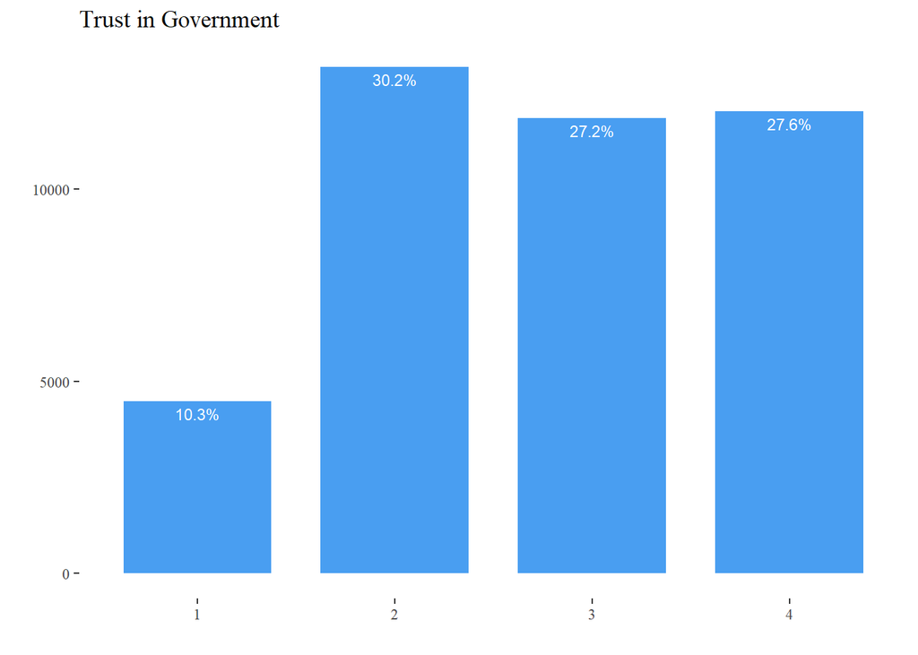

```r
t1 <- lss_comb %>%
  group_by(trust_gov_raw) %>%
  summarise(n=n()) %>%
  mutate(freq = (n / sum(n)) %>% round(3)) %>%
  mutate(freq.lab = str_c(100*freq,"%"))

t1 %>%
  drop_na(trust_gov_raw) %>%
  ggplot(aes(x=factor(trust_gov_raw),y=n))+
  geom_col(width = 0.75, alpha=0.8, fill = "dodgerblue2")+
  geom_text(aes(label=freq.lab),colour="white",vjust = 1.5,size=3)+
  labs(title = "Trust in Government",
       x = "",
       y="")+
  theme_tufte()
```

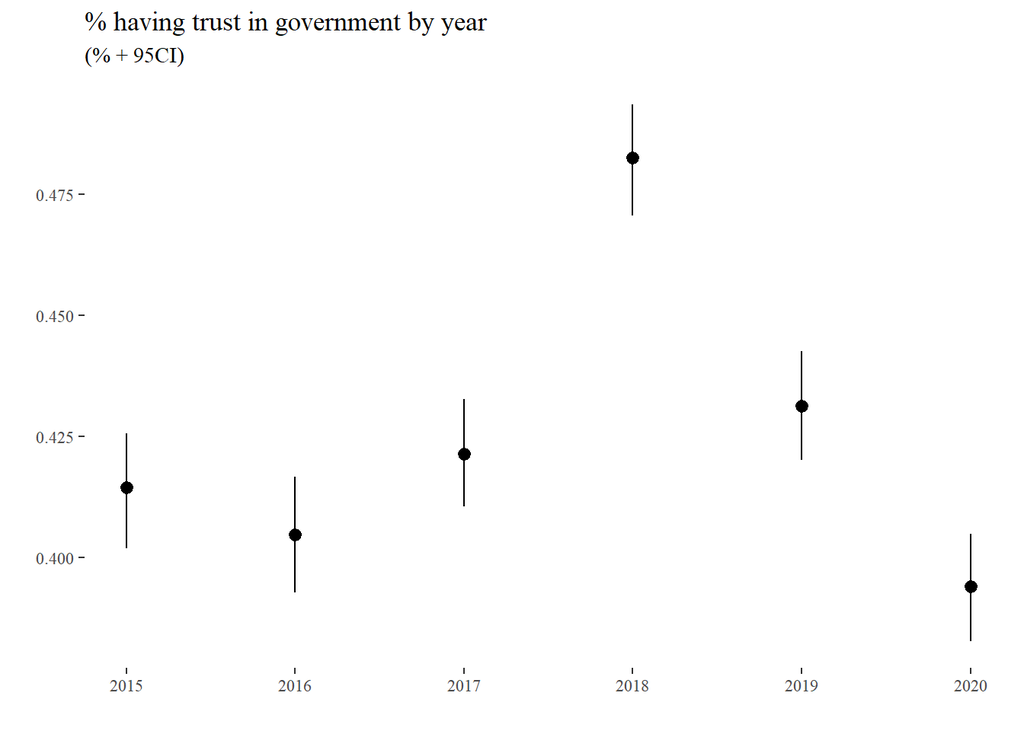

```r
lss_comb %>%
  ggplot(aes(x=year, y=(trust_gov_bi)))+
  stat_summary(geom="pointrange", fun.data = mean_cl_boot) +
  labs(title = "% having trust in government by year",
       subtitle = "(% + 95CI)",
       x = "",
       y="")+
  theme_tufte()
```

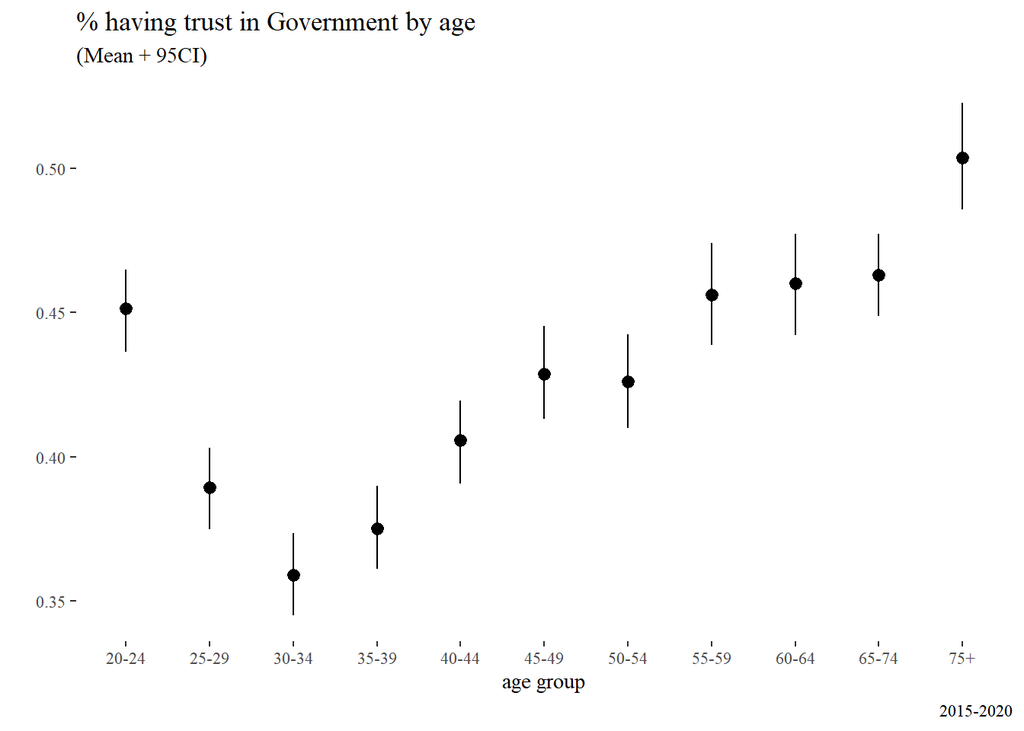

```r
lss_comb %>%
  ggplot(aes(x=age_g, y=trust_gov_bi))+
  stat_summary(geom="pointrange", fun.data = mean_cl_boot) +
  labs(title = "% having trust in Government by age",
       subtitle = "(Mean + 95CI)",
       x = "age group",
       y="",
       caption = "2015-2020")+
  theme_tufte()
```

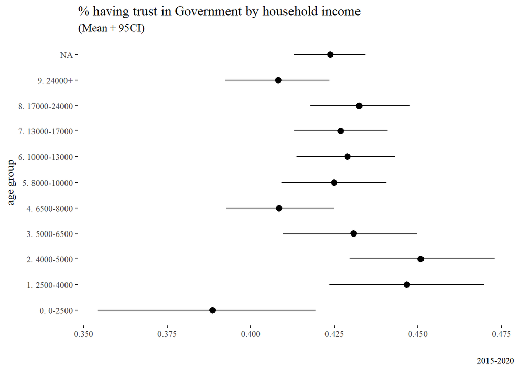

```r
lss_comb %>%
  ggplot(aes(x=household_income, y=trust_gov_bi))+
  stat_summary(geom="pointrange", fun.data = mean_cl_boot) +
  labs(title = "% having trust in Government by household income",
       subtitle = "(Mean + 95CI)",
       x = "age group",
       y="",
       caption = "2015-2020")+
  theme_tufte()+
  coord_flip()
```

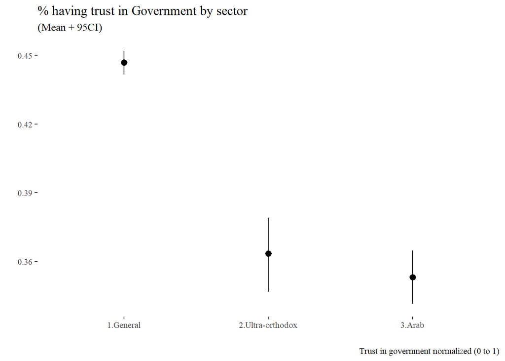

```r
lss_comb %>%
  ggplot(aes(x=sector, y=trust_gov_bi))+
  stat_summary(geom="pointrange", fun.data = mean_cl_boot) +
  labs(title = "% having trust in Government by sector",
       subtitle = "(Mean + 95CI)",
       x = "",
       y="",
       caption = "Trust in government normalized (0 to 1)")+
  theme_tufte()
```

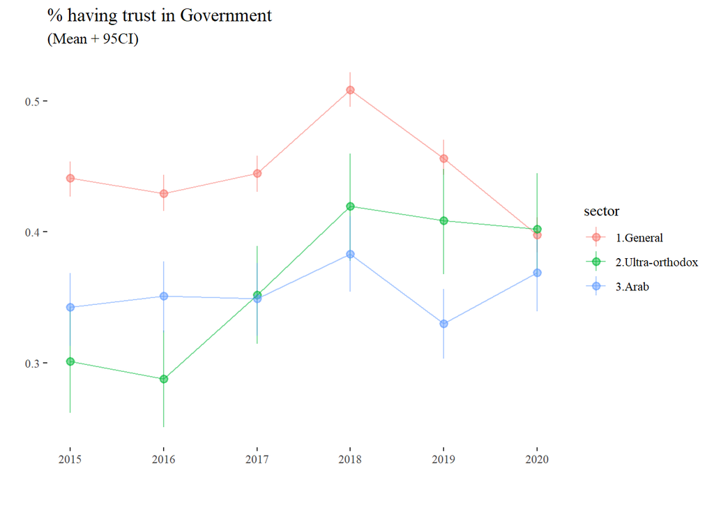

```r
lss_comb %>%
  ggplot(aes(x=year, y=trust_gov_bi,color = sector))+
  stat_summary(geom="pointrange", fun.data = mean_cl_boot,alpha=0.5) +
stat_summary(geom="line", fun.data = mean_cl_boot,alpha=0.5) +
  labs(title = "% having trust in Government",
       subtitle = "(Mean + 95CI)",
       x = "",
       y="",
       caption = "")+
  theme_tufte()
```

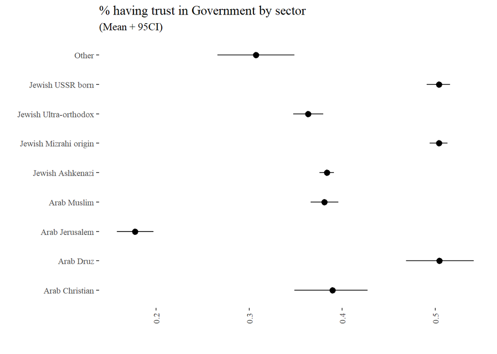

```r
lss_comb %>%
  ggplot(aes(x=sector_multiple, y=trust_gov_bi))+
  stat_summary(geom="pointrange", fun.data = mean_cl_boot) +
  labs(title = "% having trust in Government by sector",
       subtitle = "(Mean + 95CI)",
       x = "",
       y="",
       caption = "")+
  theme_tufte() +
  theme(axis.text.x = element_text(angle = 90, vjust = 0.5, hjust=1))+
  coord_flip()
```

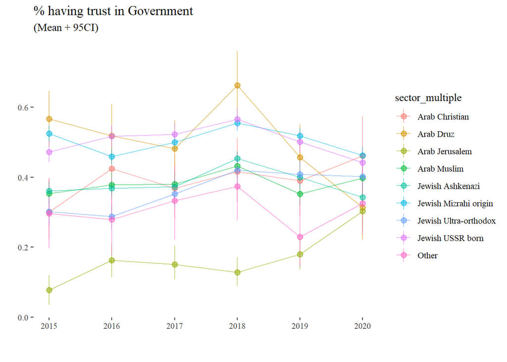

```r
lss_comb %>%
  ggplot(aes(x=year, y=trust_gov_bi,color = sector_multiple))+
  stat_summary(geom="pointrange", fun.data = mean_cl_boot,alpha=0.5) +
stat_summary(geom="line", fun.data = mean_cl_boot,alpha=0.5) +
  labs(title = "% having trust in Government",
       subtitle = "(Mean + 95CI)",
       x = "",
       y="",
       caption = "")+
  theme_tufte()
```

Weighted means:

```r
lss_comb %>%
  group_by(sector) %>%
   summarise(n = n(),
             mean_trust_gov_bi = mean(trust_gov_bi,na.rm=T) %>% round(3),
             weighted_mean_trust_gov_bi = weighted.mean(trust_gov_bi, weight,na.rm=T) %>% round(3)) %>%
  gt()
```

| sector | n | mean_trust_gov_bi | weighted_mean_trust_gov_bi |
| --- | --- | --- | --- |
| 1.General | 32339 | 0.447 | 0.448 |
| 2.Ultra-orthodox | 3436 | 0.363 | 0.366 |
| 3.Arab | 7853 | 0.353 | 0.344 |

```r
lss_comb %>%
  group_by(sector_multiple) %>%
   summarise(n = n(),
             mean_trust_gov_bi = mean(trust_gov_bi,na.rm=T) %>% round(3),
             weighted_mean_trust_gov_bi = weighted.mean(trust_gov_bi, weight,na.rm=T) %>% round(3)) %>%
  gt()
```

| sector_multiple | n | mean_trust_gov_bi | weighted_mean_trust_gov_bi |
| --- | --- | --- | --- |
| Arab Christian | 698 | 0.390 | 0.381 |
| Arab Druz | 817 | 0.504 | 0.507 |
| Arab Jerusalem | 1374 | 0.177 | 0.168 |
| Arab Muslim | 4940 | 0.381 | 0.376 |
| Jewish Ashkenazi | 14427 | 0.384 | 0.387 |
| Jewish Mizrahi origin | 10903 | 0.504 | 0.503 |
| Jewish Ultra-orthodox | 3436 | 0.363 | 0.366 |
| Jewish USSR born | 6515 | 0.504 | 0.504 |
| Other | 518 | 0.307 | 0.309 |

## Trust in Health system

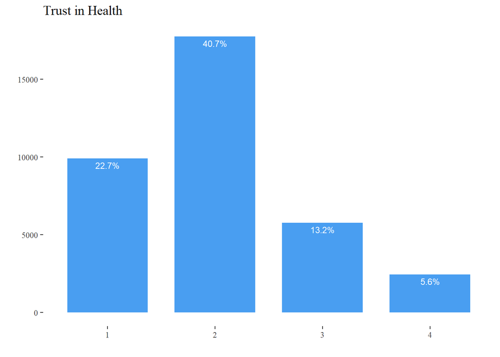

```r
t1 <- lss_comb %>%
  group_by(trust_health_raw) %>%
  summarise(n=n()) %>%
  mutate(freq = (n / sum(n)) %>% round(3)) %>%
  mutate(freq.lab = str_c(100*freq,"%"))

t1 %>%
  drop_na(trust_health_raw) %>%
  ggplot(aes(x=factor(trust_health_raw),y=n))+
  geom_col(width = 0.75, alpha=0.8, fill = "dodgerblue2")+
  geom_text(aes(label=freq.lab),colour="white",vjust = 1.5,size=3)+
  labs(title = "Trust in Health",
       x = "",
       y="")+
  theme_tufte()
```

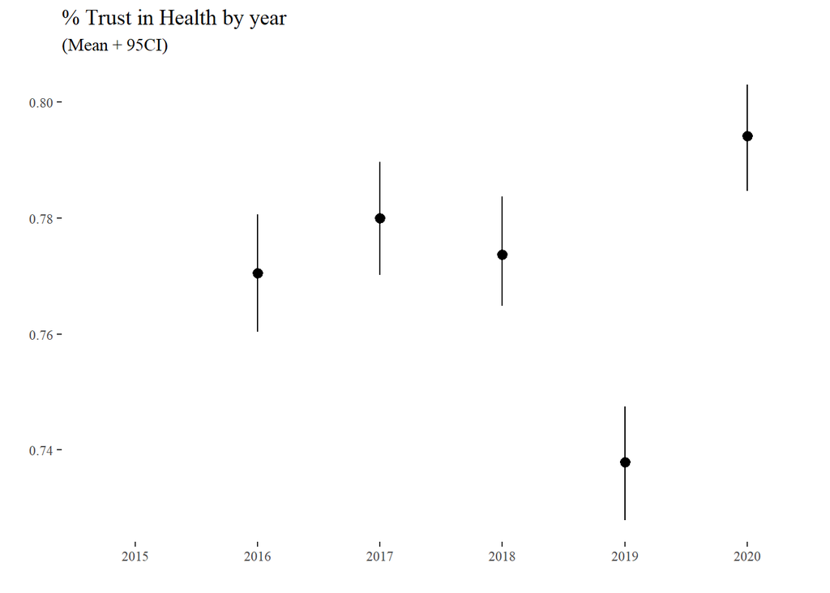

```r
lss_comb %>%
  ggplot(aes(x=factor(year), y=trust_health_bi))+
  stat_summary(geom="pointrange", fun.data = mean_cl_boot) +
  labs(title = "% Trust in Health by year",
       subtitle = "(Mean + 95CI)",
       x = "",
       y="")+
  theme_tufte()
```

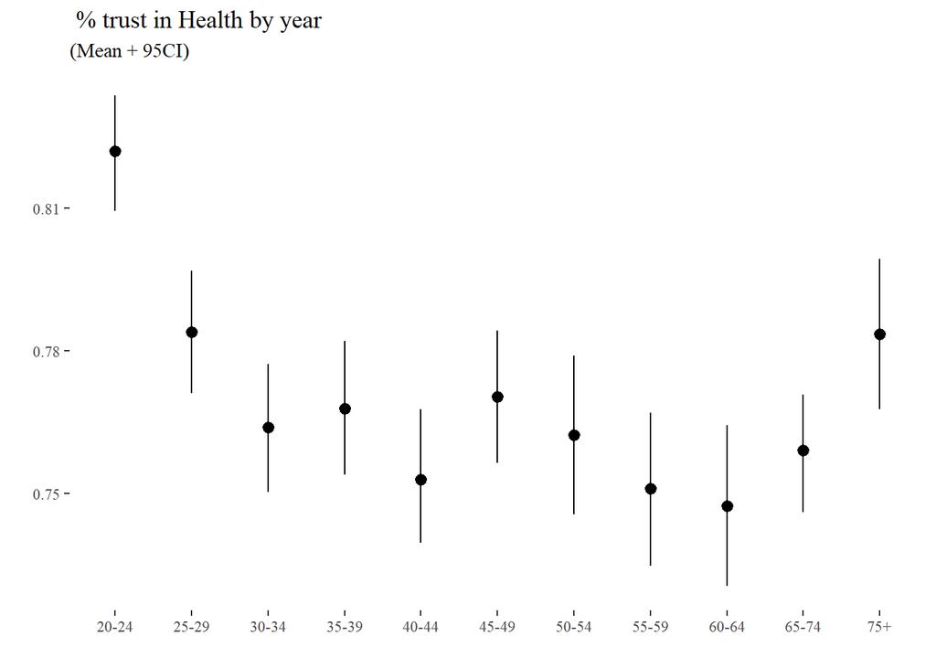

```r
lss_comb %>%
  ggplot(aes(x=age_g, y=trust_health_bi))+
  stat_summary(geom="pointrange", fun.data = mean_cl_boot) +
  labs(title = " % trust in Health by year",
       subtitle = "(Mean + 95CI)",
       x = "",
       y="")+
  theme_tufte()
```

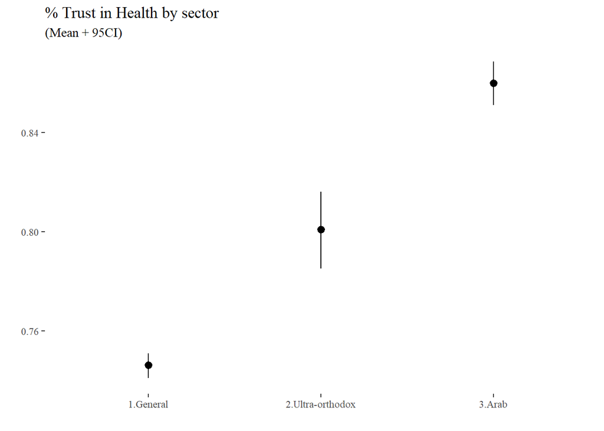

```r
lss_comb %>%
  ggplot(aes(x=sector, y=trust_health_bi))+
  stat_summary(geom="pointrange", fun.data = mean_cl_boot) +
  labs(title = "% Trust in Health by sector",
       subtitle = "(Mean + 95CI)",
       x = "",
       y="")+
  theme_tufte()
```

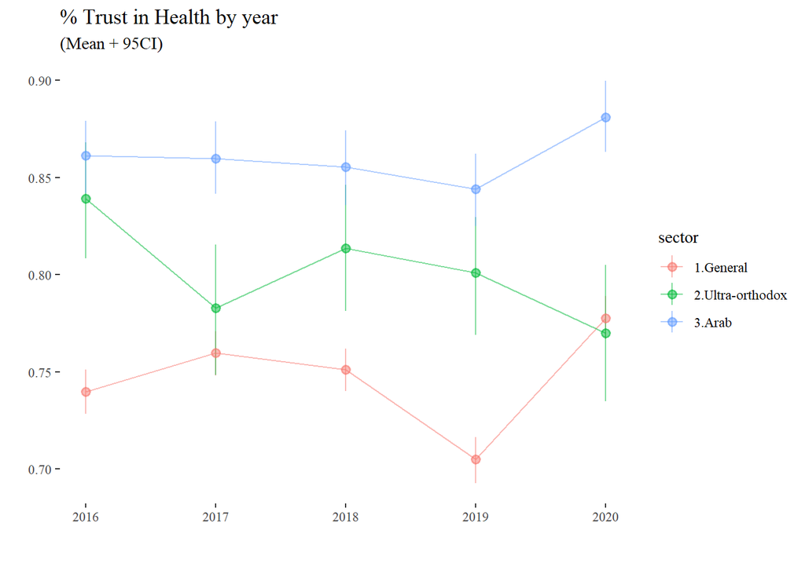

```r
lss_comb %>%
  ggplot(aes(x=year, y=trust_health_bi,color = sector))+
  stat_summary(geom="pointrange", fun.data = mean_cl_boot,alpha=0.5) +
stat_summary(geom="line", fun.data = mean_cl_boot,alpha=0.5) +
  labs(title = "% Trust in Health by year",
       subtitle = "(Mean + 95CI)",
       x = "",
       y="",
       caption = "")+
  theme_tufte()
```

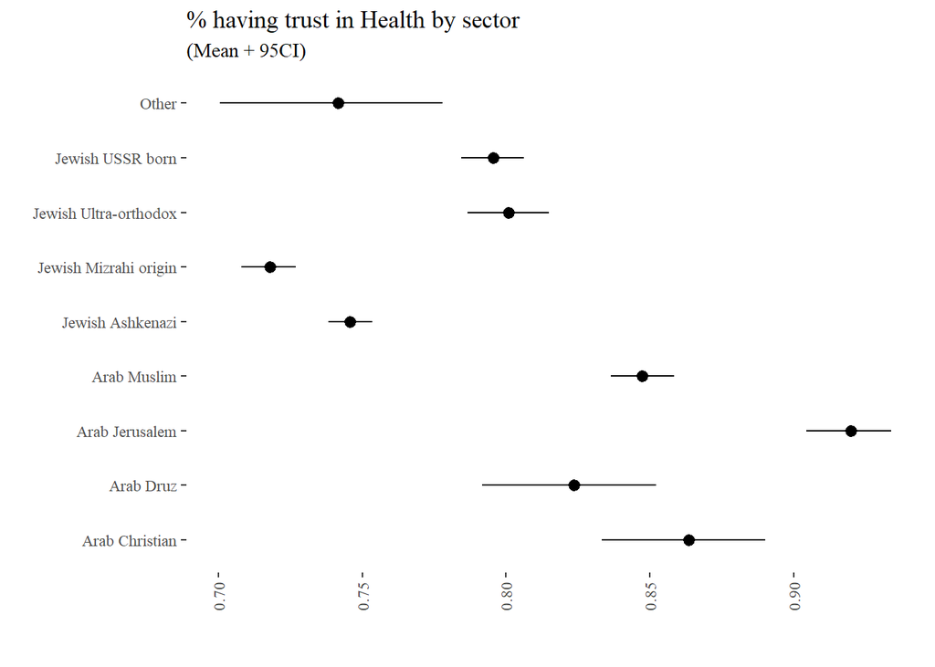

```r
lss_comb %>%
  ggplot(aes(x=sector_multiple, y=trust_health_bi))+
  stat_summary(geom="pointrange", fun.data = mean_cl_boot) +
  labs(title = "% having trust in Health by sector",
       subtitle = "(Mean + 95CI)",
       x = "",
       y="",
       caption = "")+
  theme_tufte() +
  theme(axis.text.x = element_text(angle = 90, vjust = 0.5, hjust=1))+
  coord_flip()
```

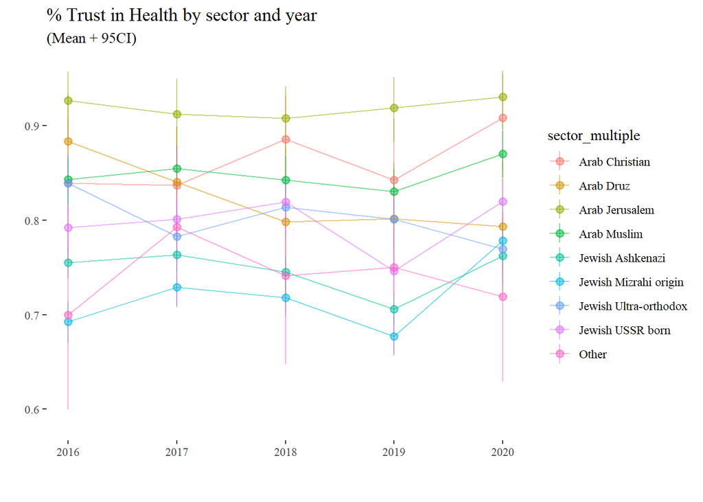

```r
lss_comb %>%
  ggplot(aes(x=year, y=trust_health_bi,color = sector_multiple))+
  stat_summary(geom="pointrange", fun.data = mean_cl_boot,alpha=0.5) +
  stat_summary(geom="line", fun.data = mean_cl_boot,alpha=0.5) +

  labs(title = "% Trust in Health by sector and year",
       subtitle = "(Mean + 95CI)",
       x = "",
       y="",
       caption = "")+
  theme_tufte()
```

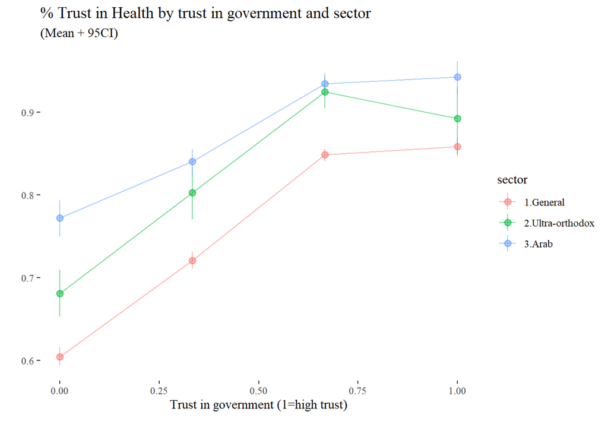

```r
lss_comb %>%
  ggplot(aes(x=trust_gov, y=trust_health_bi,color = sector))+
  stat_summary(geom="pointrange", fun.data = mean_cl_boot,alpha=0.5) +
  stat_summary(geom="line", fun.data = mean_cl_boot,alpha=0.5) +

  labs(title = "% Trust in Health by trust in government and sector",
       subtitle = "(Mean + 95CI)",
       x = "Trust in government (1=high trust)",
       y="",
       caption = "")+
  theme_tufte()
```

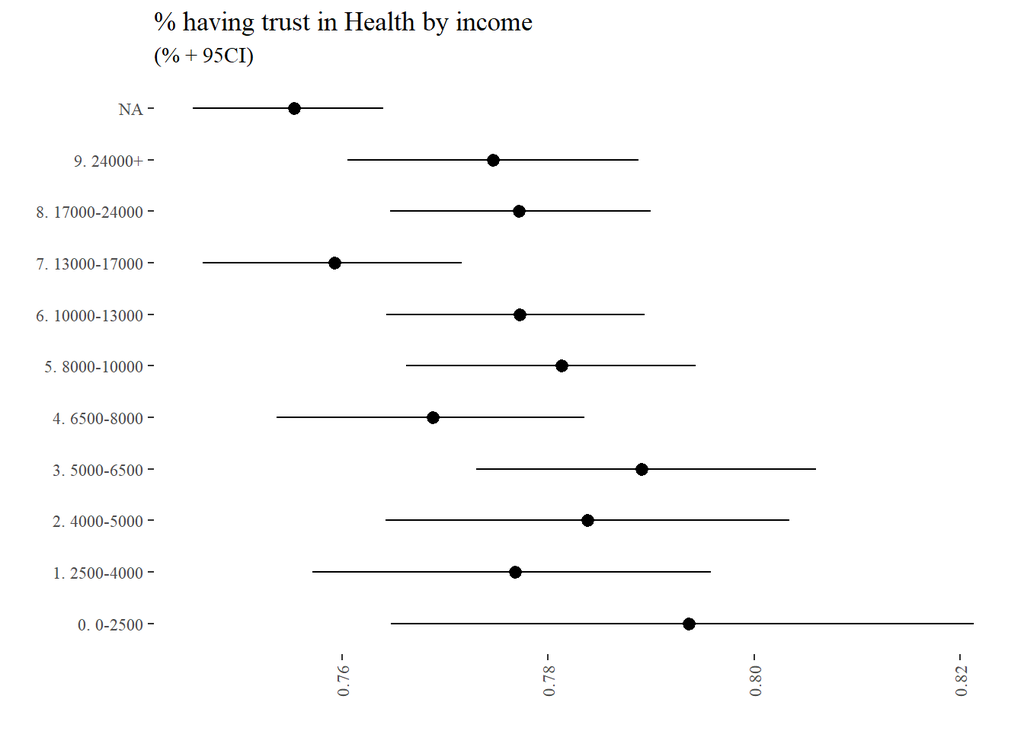

```r
lss_comb %>%
  ggplot(aes(x=household_income, y=(trust_health_bi)))+
  stat_summary(geom="pointrange", fun.data = mean_cl_boot) +
  labs(title = "% having trust in Health by income",
       subtitle = "(% + 95CI)",
       x = "",
       y="")+
  theme_tufte()+
  theme(axis.text.x = element_text(angle = 90, vjust = 0.5, hjust=1))+
  coord_flip()
```

Weighted means:

```r
lss_comb %>%
  group_by(sector) %>%
   summarise(n = n(),
             mean_trust_health_bi = mean(trust_health_bi,na.rm=T) %>% round(3),
             weighted_mean_trust_health_bi = weighted.mean(trust_health_bi, weight,na.rm=T) %>% round(3)) %>%
  gt()
```

| sector | n | mean_trust_health_bi | weighted_mean_trust_health_bi |
| --- | --- | --- | --- |
| 1.General | 32339 | 0.746 | 0.746 |
| 2.Ultra-orthodox | 3436 | 0.801 | 0.801 |
| 3.Arab | 7853 | 0.860 | 0.858 |

```r
lss_comb %>%
  group_by(sector_multiple) %>%
   summarise(n = n(),
             mean_trust_health_bi = mean(trust_health_bi,na.rm=T) %>% round(3),
             weighted_mean_trust_health_bi = weighted.mean(trust_health_bi, weight,na.rm=T) %>% round(3)) %>%
  gt()
```

| sector_multiple | n | mean_trust_health_bi | weighted_mean_trust_health_bi |
| --- | --- | --- | --- |
| Arab Christian | 698 | 0.863 | 0.867 |
| Arab Druz | 817 | 0.824 | 0.819 |
| Arab Jerusalem | 1374 | 0.920 | 0.918 |
| Arab Muslim | 4940 | 0.847 | 0.844 |
| Jewish Ashkenazi | 14427 | 0.746 | 0.748 |
| Jewish Mizrahi origin | 10903 | 0.718 | 0.717 |
| Jewish Ultra-orthodox | 3436 | 0.801 | 0.801 |
| Jewish USSR born | 6515 | 0.796 | 0.797 |
| Other | 518 | 0.742 | 0.739 |

## Performance evaluation of healthcare system

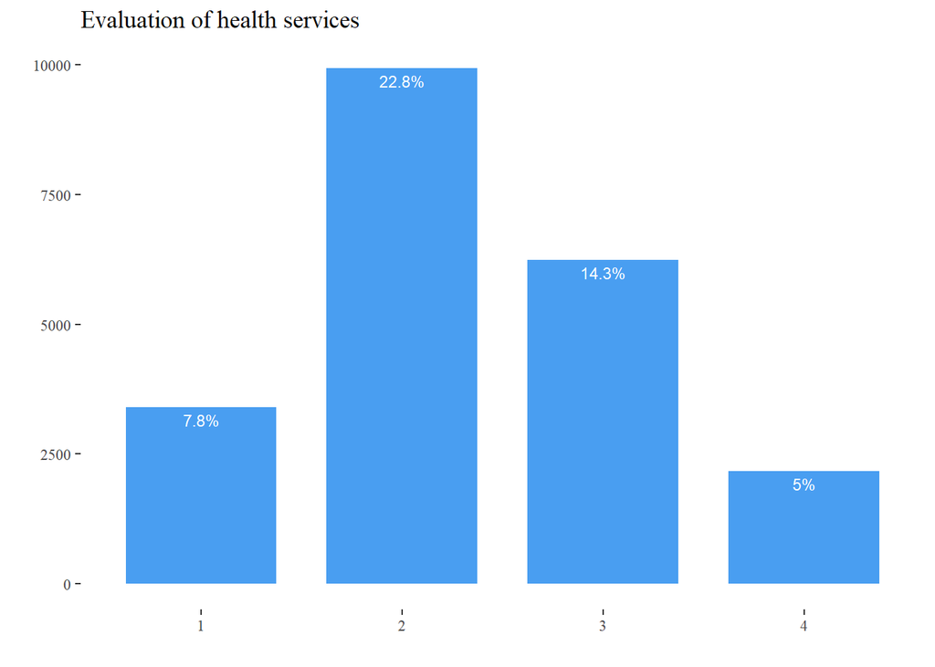

```r
t1 <- lss_comb %>%
  group_by(performance_health_raw) %>%
  summarise(n=n()) %>%
  mutate(freq = (n / sum(n)) %>% round(3)) %>%
  mutate(freq.lab = str_c(100*freq,"%"))

t1 %>%
  drop_na(performance_health_raw) %>%
  ggplot(aes(x=factor(performance_health_raw),y=n))+
  geom_col(width = 0.75, alpha=0.8, fill = "dodgerblue2")+
  geom_text(aes(label=freq.lab),colour="white",vjust = 1.5,size=3)+
  labs(title = "Evaluation of health services",
       x = "",
       y="")+
  theme_tufte()
```

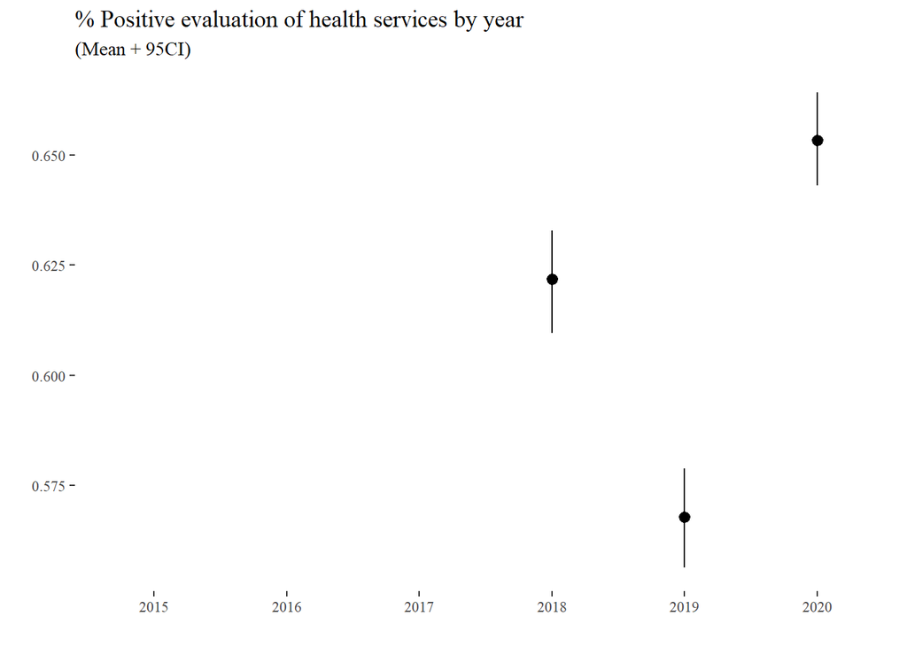

```r
lss_comb %>%
  ggplot(aes(x=factor(year), y=performance_health_bi))+
  stat_summary(geom="pointrange", fun.data = mean_cl_boot) +
  labs(title = "% Positive evaluation of health services by year",
       subtitle = "(Mean + 95CI)",
       x = "",
       y="")+
  theme_tufte()
```

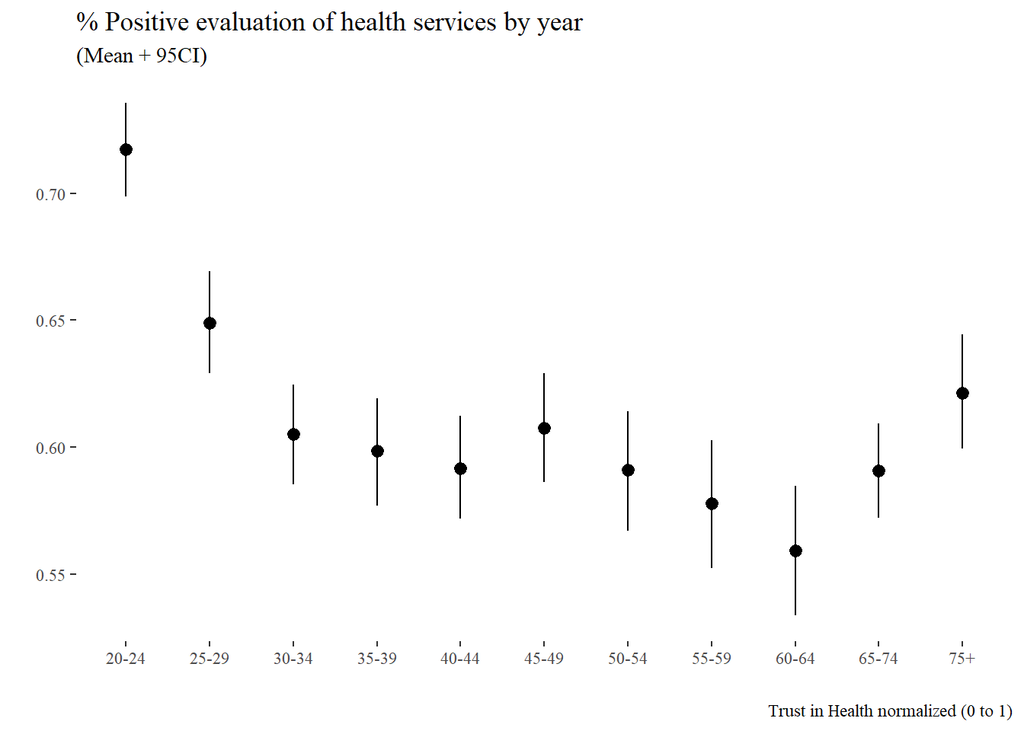

```r
lss_comb %>%
  ggplot(aes(x=age_g, y=performance_health_bi))+
  stat_summary(geom="pointrange", fun.data = mean_cl_boot) +
  labs(title = "% Positive evaluation of health services by year",
       subtitle = "(Mean + 95CI)",
       x = "",
       y="",
       caption = "Trust in Health normalized (0 to 1)")+
  theme_tufte()
```

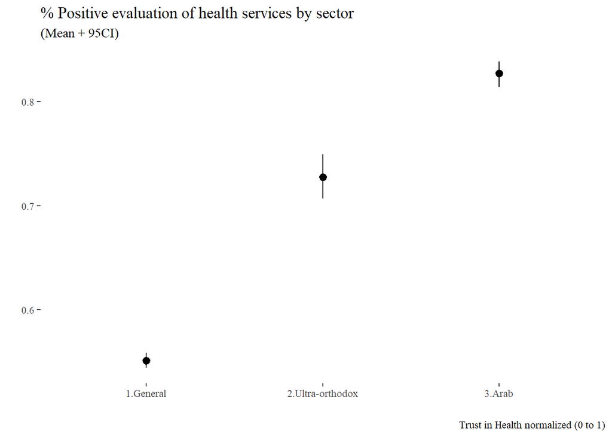

```r
lss_comb %>%
  ggplot(aes(x=sector, y=performance_health_bi))+
  stat_summary(geom="pointrange", fun.data = mean_cl_boot) +
  labs(title = "% Positive evaluation of health services by sector",
       subtitle = "(Mean + 95CI)",
       x = "",
       y="",
       caption = "Trust in Health normalized (0 to 1)")+
  theme_tufte()
```

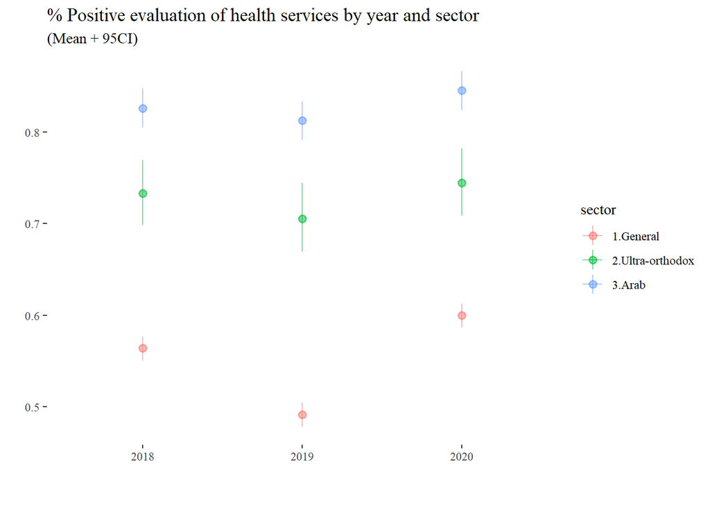

```r
lss_comb %>%
  filter(year>=2018) %>%
  ggplot(aes(x=factor(year), y=performance_health_bi,color = sector))+
  stat_summary(geom="pointrange", fun.data = mean_cl_boot,alpha=0.5) +
stat_summary(geom="line", fun.data = mean_cl_boot,alpha=0.5) +
  labs(title = "% Positive evaluation of health services by year and sector",
       subtitle = "(Mean + 95CI)",
       x = "",
       y="",
       caption = "")+
  theme_tufte()
```

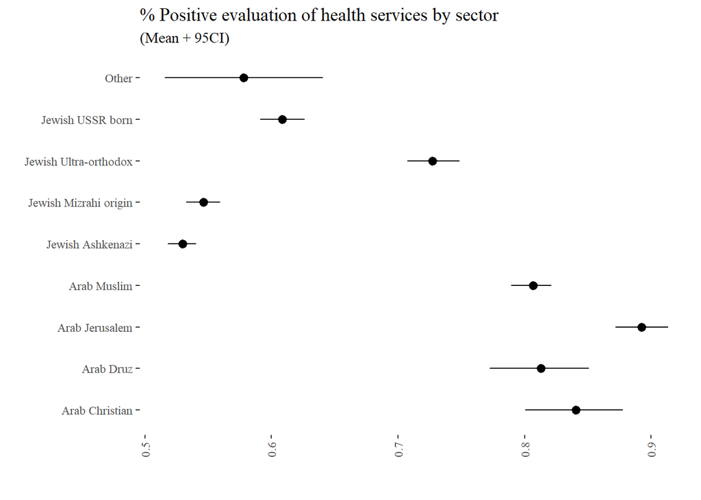

```r
lss_comb %>%
  ggplot(aes(x=sector_multiple, y=performance_health_bi))+
  stat_summary(geom="pointrange", fun.data = mean_cl_boot) +
  labs(title = "% Positive evaluation of health services by sector",
       subtitle = "(Mean + 95CI)",
       x = "",
       y="",
       caption = "")+
  theme_tufte() +
  theme(axis.text.x = element_text(angle = 90, vjust = 0.5, hjust=1))+
  coord_flip()
```

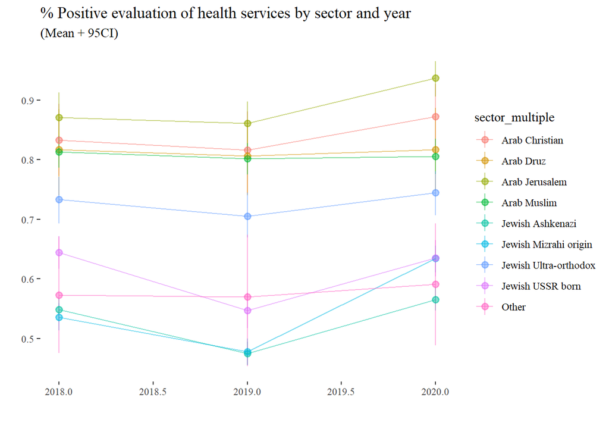

```r
lss_comb %>%
  ggplot(aes(x=year, y=performance_health_bi,color = sector_multiple))+
  stat_summary(geom="pointrange", fun.data = mean_cl_boot,alpha=0.5) +
  stat_summary(geom="line", fun.data = mean_cl_boot,alpha=0.5) +

  labs(title = "% Positive evaluation of health services by sector and year",
       subtitle = "(Mean + 95CI)",
       x = "",
       y="",
       caption = "")+
  theme_tufte()
```

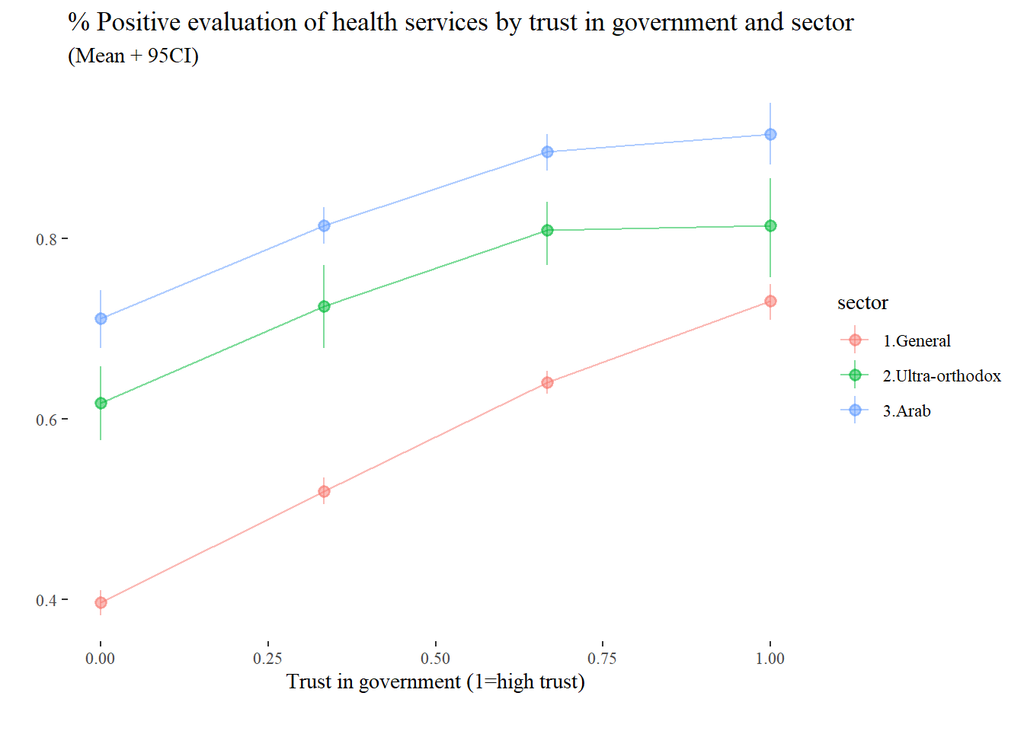

```r
lss_comb %>%
  ggplot(aes(x=trust_gov, y=performance_health_bi,color = sector))+
  stat_summary(geom="pointrange", fun.data = mean_cl_boot,alpha=0.5) +
  stat_summary(geom="line", fun.data = mean_cl_boot,alpha=0.5) +

  labs(title = "% Positive evaluation of health services by trust in government and sector",
       subtitle = "(Mean + 95CI)",
       x = "Trust in government (1=high trust)",
       y="",
       caption = "")+
  theme_tufte()
```

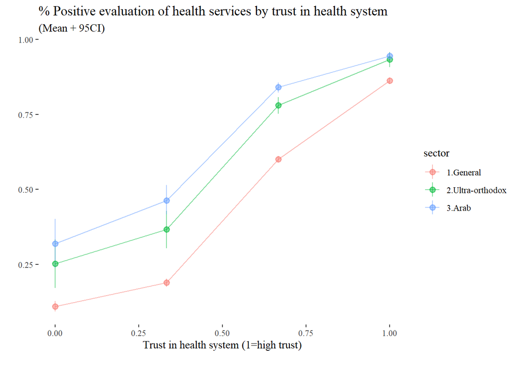

```r
lss_comb %>%
  ggplot(aes(x=trust_health, y=performance_health_bi,color = sector))+
  stat_summary(geom="pointrange", fun.data = mean_cl_boot,alpha=0.5) +
  stat_summary(geom="line", fun.data = mean_cl_boot,alpha=0.5) +

  labs(title = "% Positive evaluation of health services by trust in health system",
       subtitle = "(Mean + 95CI)",
       x = "Trust in health system (1=high trust)",
       y="",
       caption = "")+
  theme_tufte()
```

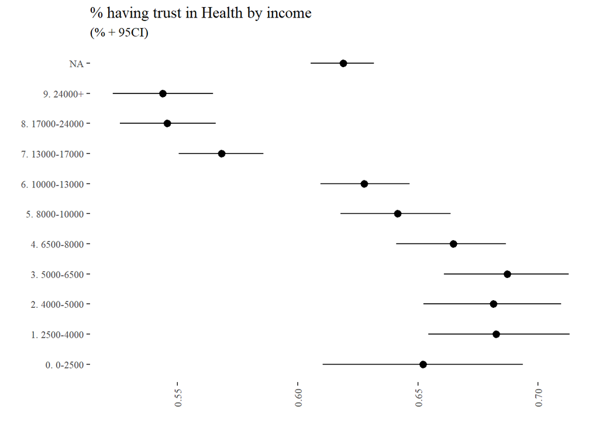

```r
lss_comb %>%
  ggplot(aes(x=household_income, y=(performance_health_bi)))+
  stat_summary(geom="pointrange", fun.data = mean_cl_boot) +
  labs(title = "% having trust in Health by income",
       subtitle = "(% + 95CI)",
       x = "",
       y="")+
  theme_tufte()+
  theme(axis.text.x = element_text(angle = 90, vjust = 0.5, hjust=1))+
  coord_flip()
```

Weighted means:

```r
lss_comb %>%
  group_by(sector) %>%
   summarise(n = n(),
             mean_trust_health_bi = mean(trust_health_bi,na.rm=T) %>% round(3),
             weighted_mean_trust_health_bi = weighted.mean(trust_health_bi, weight,na.rm=T) %>% round(3)) %>%
  gt()
```

| sector | n | mean_trust_health_bi | weighted_mean_trust_health_bi |
| --- | --- | --- | --- |
| 1.General | 32339 | 0.746 | 0.746 |
| 2.Ultra-orthodox | 3436 | 0.801 | 0.801 |
| 3.Arab | 7853 | 0.860 | 0.858 |

```r
lss_comb %>%
  group_by(sector_multiple) %>%
   summarise(n = n(),
             mean_trust_health_bi = mean(trust_health_bi,na.rm=T) %>% round(3),
             weighted_mean_trust_health_bi = weighted.mean(trust_health_bi, weight,na.rm=T) %>% round(3)) %>%
  gt()
```

| sector_multiple | n | mean_trust_health_bi | weighted_mean_trust_health_bi |
| --- | --- | --- | --- |
| Arab Christian | 698 | 0.863 | 0.867 |
| Arab Druz | 817 | 0.824 | 0.819 |
| Arab Jerusalem | 1374 | 0.920 | 0.918 |
| Arab Muslim | 4940 | 0.847 | 0.844 |
| Jewish Ashkenazi | 14427 | 0.746 | 0.748 |
| Jewish Mizrahi origin | 10903 | 0.718 | 0.717 |
| Jewish Ultra-orthodox | 3436 | 0.801 | 0.801 |
| Jewish USSR born | 6515 | 0.796 | 0.797 |
| Other | 518 | 0.742 | 0.739 |

# Summary tables

```r
lss_comb %>%
  select(trust_gov_raw,
        trust_gov_bi,
        trust_health,
        trust_health_bi,
        performance_health_raw,
        performance_health_bi,
        trust_local_gov_raw) %>%
  tbl_summary()
```

| **Characteristic** | **N = 43,628**<sup>1</sup> |
| --- | --- |
| trust_gov_raw |  |
| 1 | 4,481 (11%) |
| 2 | 13,184 (32%) |
| 3 | 11,853 (29%) |
| 4 | 12,022 (29%) |
| Unknown | 2,088 |
| trust_gov_bi | 17,665 (43%) |
| Unknown | 2,088 |
| trust_health |  |
| 0 | 2,447 (6.8%) |
| 0.333333333333333 | 5,771 (16%) |
| 0.666666666666667 | 17,745 (49%) |
| 1 | 9,909 (28%) |
| Unknown | 7,756 |
| trust_health_bi | 27,654 (77%) |
| Unknown | 7,756 |
| performance_health_raw |  |
| 1 | 3,408 (16%) |
| 2 | 9,934 (46%) |
| 3 | 6,237 (29%) |
| 4 | 2,169 (10.0%) |
| Unknown | 21,880 |
| performance_health_bi | 13,342 (61%) |
| Unknown | 21,880 |
| trust_local_gov_raw |  |
| 1 | 1,058 (16%) |
| 2 | 3,233 (48%) |
| 3 | 1,488 (22%) |
| 4 | 966 (14%) |
| Unknown | 36,883 |

<sup>*1*</sup> n (%)

```r
lss_comb %>%
  select(year,
        trust_gov_raw,
        trust_gov_bi,
        trust_health,
        trust_health_bi,
        performance_health_raw,
        performance_health_bi,
        trust_local_gov_raw) %>%
  tbl_summary(by = year)
```

| **Characteristic** | **2015**, N = 7,078<sup>1</sup> | **2016**, N = 7,048<sup>1</sup> | **2017**, N = 7,230<sup>1</sup> | **2018**, N = 7,448<sup>1</sup> | **2019**, N = 7,575<sup>1</sup> | **2020**, N = 7,249<sup>1</sup> |
| --- | --- | --- | --- | --- | --- | --- |
| trust_gov_raw |  |  |  |  |  |  |
| 1 | 626 (9.2%) | 604 (9.0%) | 734 (11%) | 946 (13%) | 830 (11%) | 741 (11%) |
| 2 | 2,197 (32%) | 2,109 (31%) | 2,155 (31%) | 2,482 (35%) | 2,299 (32%) | 1,942 (29%) |
| 3 | 2,090 (31%) | 1,966 (29%) | 1,934 (28%) | 1,908 (27%) | 2,113 (29%) | 1,842 (27%) |
| 4 | 1,898 (28%) | 2,024 (30%) | 2,034 (30%) | 1,768 (25%) | 2,014 (28%) | 2,284 (34%) |
| Unknown | 267 | 345 | 373 | 344 | 319 | 440 |
| trust_gov_bi | 2,823 (41%) | 2,713 (40%) | 2,889 (42%) | 3,428 (48%) | 3,129 (43%) | 2,683 (39%) |
| Unknown | 267 | 345 | 373 | 344 | 319 | 440 |
| trust_health |  |  |  |  |  |  |
| 0 | 0 (NA%) | 490 (7.1%) | 488 (6.9%) | 404 (5.5%) | 616 (8.3%) | 449 (6.4%) |
| 0.333333333333333 | 0 (NA%) | 1,095 (16%) | 1,074 (15%) | 1,257 (17%) | 1,340 (18%) | 1,005 (14%) |
| 0.666666666666667 | 0 (NA%) | 3,290 (48%) | 3,557 (50%) | 3,798 (52%) | 3,587 (48%) | 3,513 (50%) |
| 1 | 0 (NA%) | 2,032 (29%) | 1,979 (28%) | 1,882 (26%) | 1,921 (26%) | 2,095 (30%) |
| Unknown | 7,078 | 141 | 132 | 107 | 111 | 187 |
| trust_health_bi | 0 (NA%) | 5,322 (77%) | 5,536 (78%) | 5,680 (77%) | 5,508 (74%) | 5,608 (79%) |
| Unknown | 7,078 | 141 | 132 | 107 | 111 | 187 |
| performance_health_raw |  |  |  |  |  |  |
| 1 | 0 (NA%) | 0 (NA%) | 0 (NA%) | 1,059 (15%) | 1,068 (14%) | 1,281 (18%) |
| 2 | 0 (NA%) | 0 (NA%) | 0 (NA%) | 3,482 (48%) | 3,151 (42%) | 3,301 (47%) |
| 3 | 0 (NA%) | 0 (NA%) | 0 (NA%) | 2,143 (29%) | 2,297 (31%) | 1,797 (26%) |
| 4 | 0 (NA%) | 0 (NA%) | 0 (NA%) | 619 (8.5%) | 915 (12%) | 635 (9.1%) |
| Unknown | 7,078 | 7,048 | 7,230 | 145 | 144 | 235 |
| performance_health_bi | 0 (NA%) | 0 (NA%) | 0 (NA%) | 4,541 (62%) | 4,219 (57%) | 4,582 (65%) |
| Unknown | 7,078 | 7,048 | 7,230 | 145 | 144 | 235 |
| trust_local_gov_raw |  |  |  |  |  |  |
| 1 | 1,058 (16%) | 0 (NA%) | 0 (NA%) | 0 (NA%) | 0 (NA%) | 0 (NA%) |
| 2 | 3,233 (48%) | 0 (NA%) | 0 (NA%) | 0 (NA%) | 0 (NA%) | 0 (NA%) |
| 3 | 1,488 (22%) | 0 (NA%) | 0 (NA%) | 0 (NA%) | 0 (NA%) | 0 (NA%) |
| 4 | 966 (14%) | 0 (NA%) | 0 (NA%) | 0 (NA%) | 0 (NA%) | 0 (NA%) |
| Unknown | 333 | 7,048 | 7,230 | 7,448 | 7,575 | 7,249 |

<sup>*1*</sup> n (%)

```r
lss_comb %>%
  select(sector,
         year,
        trust_gov_raw,
        trust_gov_bi,
        trust_health,
        trust_health_bi,
        performance_health_raw,
        performance_health_bi,
        trust_local_gov_raw) %>%
  tbl_summary(by = sector)
```

| **Characteristic** | **1.General**, N = 32,339<sup>1</sup> | **2.Ultra-orthodox**, N = 3,436<sup>1</sup> | **3.Arab**, N = 7,853<sup>1</sup> |
| --- | --- | --- | --- |
| year |  |  |  |
| 2015 | 5,290 (16%) | 527 (15%) | 1,261 (16%) |
| 2016 | 5,141 (16%) | 565 (16%) | 1,342 (17%) |
| 2017 | 5,291 (16%) | 589 (17%) | 1,350 (17%) |
| 2018 | 5,598 (17%) | 563 (16%) | 1,287 (16%) |
| 2019 | 5,576 (17%) | 602 (18%) | 1,397 (18%) |
| 2020 | 5,443 (17%) | 590 (17%) | 1,216 (15%) |
| trust_gov_raw |  |  |  |
| 1 | 3,644 (12%) | 270 (8.2%) | 567 (8.5%) |
| 2 | 10,470 (33%) | 931 (28%) | 1,783 (27%) |
| 3 | 8,603 (27%) | 777 (24%) | 2,473 (37%) |
| 4 | 8,863 (28%) | 1,327 (40%) | 1,832 (28%) |
| Unknown | 759 | 131 | 1,198 |
| trust_gov_bi | 14,114 (45%) | 1,201 (36%) | 2,350 (35%) |
| Unknown | 759 | 131 | 1,198 |
| trust_health |  |  |  |
| 0 | 2,028 (7.6%) | 191 (6.7%) | 228 (3.6%) |
| 0.333333333333333 | 4,724 (18%) | 376 (13%) | 671 (10%) |
| 0.666666666666667 | 13,443 (51%) | 1,647 (58%) | 2,655 (41%) |
| 1 | 6,416 (24%) | 634 (22%) | 2,859 (45%) |
| Unknown | 5,728 | 588 | 1,440 |
| trust_health_bi | 19,859 (75%) | 2,281 (80%) | 5,514 (86%) |
| Unknown | 5,728 | 588 | 1,440 |
| performance_health_raw |  |  |  |
| 1 | 1,785 (11%) | 431 (25%) | 1,192 (31%) |
| 2 | 7,162 (44%) | 799 (47%) | 1,973 (52%) |
| 3 | 5,358 (33%) | 347 (21%) | 532 (14%) |
| 4 | 1,925 (12%) | 114 (6.7%) | 130 (3.4%) |
| Unknown | 16,109 | 1,745 | 4,026 |
| performance_health_bi | 8,947 (55%) | 1,230 (73%) | 3,165 (83%) |
| Unknown | 16,109 | 1,745 | 4,026 |
| trust_local_gov_raw |  |  |  |
| 1 | 876 (17%) | 71 (14%) | 111 (9.3%) |
| 2 | 2,626 (52%) | 240 (48%) | 367 (31%) |
| 3 | 1,052 (21%) | 104 (21%) | 332 (28%) |
| 4 | 491 (9.7%) | 88 (17%) | 387 (32%) |
| Unknown | 27,294 | 2,933 | 6,656 |

<sup>*1*</sup> n (%)

```r
lss_comb %>%
  select(sector_multiple,
        russian_ole,
        mizrahi_origin,
        household_income,
        district_lab,
        trust_general,
        trust_gov_raw,
        trust_gov_bi,
        trust_health,
        trust_health_bi,
        performance_health_raw,
        performance_health_bi,
        trust_local_gov_raw) %>%
  tbl_summary(by = sector_multiple)
```

| **Characteristic** | **Arab Christian**, N = 698<sup>1</sup> | **Arab Druz**, N = 817<sup>1</sup> | **Arab Jerusalem**, N = 1,374<sup>1</sup> | **Arab Muslim**, N = 4,940<sup>1</sup> | **Jewish Ashkenazi**, N = 14,427<sup>1</sup> | **Jewish Mizrahi origin**, N = 10,903<sup>1</sup> | **Jewish Ultra-orthodox**, N = 3,436<sup>1</sup> | **Jewish USSR born**, N = 6,515<sup>1</sup> | **Other**, N = 518<sup>1</sup> |
| --- | --- | --- | --- | --- | --- | --- | --- | --- | --- |
| russian_ole | 1 (0.1%) | 0 (0%) | 1 (<0.1%) | 18 (0.4%) | 0 (0%) | 0 (0%) | 79 (2.3%) | 6,515 (100%) | 0 (0%) |
| mizrahi_origin | 0 (0%) | 0 (0%) | 0 (0%) | 0 (0%) | 0 (0%) | 10,903 (100%) | 874 (25%) | 0 (0%) | 121 (23%) |
| household_income |  |  |  |  |  |  |  |  |  |
| 0. 0-2500 | 15 (2.8%) | 24 (3.8%) | 145 (12%) | 179 (4.7%) | 202 (1.9%) | 185 (2.2%) | 108 (4.1%) | 90 (1.7%) | 14 (3.9%) |
| 1. 2500-4000 | 45 (8.4%) | 56 (8.8%) | 121 (9.9%) | 411 (11%) | 286 (2.7%) | 390 (4.6%) | 190 (7.2%) | 534 (9.9%) | 20 (5.5%) |
| 2. 4000-5000 | 31 (5.8%) | 37 (5.8%) | 178 (15%) | 351 (9.2%) | 305 (2.8%) | 375 (4.4%) | 251 (9.6%) | 502 (9.3%) | 23 (6.3%) |
| 3. 5000-6500 | 42 (7.8%) | 69 (11%) | 243 (20%) | 437 (12%) | 458 (4.3%) | 545 (6.4%) | 309 (12%) | 511 (9.5%) | 28 (7.7%) |
| 4. 6500-8000 | 54 (10%) | 72 (11%) | 181 (15%) | 501 (13%) | 785 (7.3%) | 772 (9.1%) | 470 (18%) | 499 (9.2%) | 27 (7.4%) |
| 5. 8000-10000 | 70 (13%) | 82 (13%) | 179 (15%) | 521 (14%) | 1,093 (10%) | 1,044 (12%) | 463 (18%) | 635 (12%) | 47 (13%) |
| 6. 10000-13000 | 74 (14%) | 100 (16%) | 126 (10%) | 484 (13%) | 1,486 (14%) | 1,325 (16%) | 380 (14%) | 828 (15%) | 52 (14%) |
| 7. 13000-17000 | 91 (17%) | 93 (15%) | 31 (2.5%) | 468 (12%) | 2,091 (19%) | 1,653 (19%) | 282 (11%) | 820 (15%) | 61 (17%) |
| 8. 17000-24000 | 70 (13%) | 60 (9.4%) | 14 (1.1%) | 284 (7.5%) | 2,111 (20%) | 1,305 (15%) | 115 (4.4%) | 619 (11%) | 54 (15%) |
| 9. 24000+ | 44 (8.2%) | 43 (6.8%) | 3 (0.2%) | 163 (4.3%) | 1,948 (18%) | 907 (11%) | 54 (2.1%) | 369 (6.8%) | 37 (10%) |
| Unknown | 162 | 181 | 153 | 1,141 | 3,662 | 2,402 | 814 | 1,108 | 155 |
| district_lab |  |  |  |  |  |  |  |  |  |
| 1.Jerusalem | 68 (9.7%) | 0 (0%) | 1,374 (100%) | 52 (1.1%) | 1,197 (8.3%) | 784 (7.2%) | 1,113 (32%) | 240 (3.7%) | 60 (12%) |
| 2.North | 477 (68%) | 659 (81%) | 0 (0%) | 2,852 (58%) | 1,354 (9.4%) | 1,230 (11%) | 163 (4.7%) | 792 (12%) | 74 (14%) |
| 3.Haifa | 106 (15%) | 153 (19%) | 0 (0%) | 933 (19%) | 1,708 (12%) | 1,130 (10%) | 145 (4.2%) | 1,199 (18%) | 86 (17%) |
| 4.Center | 17 (2.4%) | 1 (0.1%) | 0 (0%) | 597 (12%) | 4,748 (33%) | 3,428 (31%) | 464 (14%) | 1,606 (25%) | 90 (17%) |
| 5.Tel Aviv | 23 (3.3%) | 1 (0.1%) | 0 (0%) | 67 (1.4%) | 3,478 (24%) | 2,075 (19%) | 751 (22%) | 1,046 (16%) | 134 (26%) |
| 6.South | 7 (1.0%) | 2 (0.2%) | 0 (0%) | 438 (8.9%) | 1,278 (8.9%) | 1,926 (18%) | 378 (11%) | 1,500 (23%) | 63 (12%) |
| 7.Yosh | 0 (0%) | 1 (0.1%) | 0 (0%) | 1 (<0.1%) | 664 (4.6%) | 330 (3.0%) | 422 (12%) | 132 (2.0%) | 11 (2.1%) |
| trust_general | 60 (12%) | 63 (12%) | 68 (6.9%) | 495 (16%) | 5,240 (53%) | 2,861 (41%) | 1,001 (45%) | 1,875 (46%) | 163 (50%) |
| Unknown | 217 | 304 | 383 | 1,781 | 4,622 | 3,919 | 1,195 | 2,408 | 190 |
| trust_gov_raw |  |  |  |  |  |  |  |  |  |
| 1 | 59 (10%) | 106 (15%) | 16 (1.2%) | 386 (9.6%) | 1,132 (7.9%) | 1,781 (17%) | 270 (8.2%) | 691 (11%) | 40 (8.2%) |
| 2 | 169 (29%) | 249 (35%) | 219 (17%) | 1,146 (28%) | 4,337 (30%) | 3,597 (34%) | 931 (28%) | 2,427 (39%) | 109 (22%) |
| 3 | 198 (34%) | 173 (25%) | 736 (56%) | 1,362 (34%) | 4,094 (29%) | 2,663 (25%) | 777 (24%) | 1,740 (28%) | 110 (23%) |
| 4 | 159 (27%) | 176 (25%) | 353 (27%) | 1,131 (28%) | 4,689 (33%) | 2,632 (25%) | 1,327 (40%) | 1,329 (21%) | 226 (47%) |
| Unknown | 113 | 113 | 50 | 915 | 175 | 230 | 131 | 328 | 33 |
| trust_gov_bi | 228 (39%) | 355 (50%) | 235 (18%) | 1,532 (38%) | 5,469 (38%) | 5,378 (50%) | 1,201 (36%) | 3,118 (50%) | 149 (31%) |
| Unknown | 113 | 113 | 50 | 915 | 175 | 230 | 131 | 328 | 33 |
| trust_health |  |  |  |  |  |  |  |  |  |
| 0 | 20 (3.5%) | 31 (4.9%) | 11 (0.9%) | 163 (4.1%) | 915 (7.6%) | 815 (9.2%) | 191 (6.7%) | 254 (4.8%) | 47 (11%) |
| 0.333333333333333 | 57 (10%) | 80 (13%) | 87 (7.1%) | 445 (11%) | 2,152 (18%) | 1,692 (19%) | 376 (13%) | 822 (16%) | 60 (14%) |
| 0.666666666666667 | 271 (48%) | 273 (43%) | 477 (39%) | 1,624 (41%) | 6,211 (51%) | 4,251 (48%) | 1,647 (58%) | 2,795 (53%) | 196 (47%) |
| 1 | 216 (38%) | 245 (39%) | 647 (53%) | 1,746 (44%) | 2,788 (23%) | 2,128 (24%) | 634 (22%) | 1,394 (26%) | 111 (27%) |
| Unknown | 134 | 188 | 152 | 962 | 2,361 | 2,017 | 588 | 1,250 | 104 |
| trust_health_bi | 487 (86%) | 518 (82%) | 1,124 (92%) | 3,370 (85%) | 8,999 (75%) | 6,379 (72%) | 2,281 (80%) | 4,189 (80%) | 307 (74%) |
| Unknown | 134 | 188 | 152 | 962 | 2,361 | 2,017 | 588 | 1,250 | 104 |
| performance_health_raw |  |  |  |  |  |  |  |  |  |
| 1 | 98 (28%) | 107 (29%) | 283 (37%) | 703 (30%) | 763 (10%) | 648 (12%) | 431 (25%) | 342 (11%) | 33 (13%) |
| 2 | 197 (56%) | 193 (52%) | 407 (53%) | 1,167 (50%) | 3,230 (43%) | 2,219 (42%) | 799 (47%) | 1,607 (50%) | 115 (45%) |
| 3 | 42 (12%) | 51 (14%) | 71 (9.2%) | 365 (16%) | 2,543 (34%) | 1,701 (32%) | 347 (21%) | 1,045 (33%) | 72 (28%) |
| 4 | 14 (4.0%) | 18 (4.9%) | 12 (1.6%) | 83 (3.6%) | 1,004 (13%) | 679 (13%) | 114 (6.7%) | 209 (6.5%) | 36 (14%) |
| Unknown | 347 | 448 | 601 | 2,622 | 6,887 | 5,656 | 1,745 | 3,312 | 262 |
| performance_health_bi | 295 (84%) | 300 (81%) | 690 (89%) | 1,870 (81%) | 3,993 (53%) | 2,867 (55%) | 1,230 (73%) | 1,949 (61%) | 148 (58%) |
| Unknown | 347 | 448 | 601 | 2,622 | 6,887 | 5,656 | 1,745 | 3,312 | 262 |
| trust_local_gov_raw |  |  |  |  |  |  |  |  |  |
| 1 | 10 (9.2%) | 18 (11%) | 0 (0%) | 83 (11%) | 397 (19%) | 366 (20%) | 71 (14%) | 100 (9.9%) | 13 (16%) |
| 2 | 37 (34%) | 55 (34%) | 14 (9.9%) | 261 (33%) | 1,145 (54%) | 913 (50%) | 240 (48%) | 529 (52%) | 39 (49%) |
| 3 | 29 (27%) | 39 (24%) | 60 (43%) | 204 (26%) | 399 (19%) | 354 (19%) | 104 (21%) | 281 (28%) | 18 (22%) |
| 4 | 33 (30%) | 51 (31%) | 67 (48%) | 236 (30%) | 189 (8.9%) | 192 (11%) | 88 (17%) | 100 (9.9%) | 10 (12%) |
| Unknown | 589 | 654 | 1,233 | 4,156 | 12,297 | 9,078 | 2,933 | 5,505 | 438 |

<sup>*1*</sup> n (%)